# Spin-City common garden

Katrien (data from Lukas)

2024-06-19

**analysis weight spiderlings and urbanisation context mother** 2022 spiderlings from mothers with a different urbanisation context : High - high vs low - low were grown under 4 treatments (combination of 2 temperature treatments and 2 diet treatments) Low Food - Low Temperature (20°C) Low Food - High Temperature (24°C) High Food - Low Temperature (20°C) High Food - high Temperature (24°C)

#data setup

currently restricted only to the data of the common garden with treatments and also restricted to the ones we have weights of

```r
here()
```

```
## [1] "C:/Users/kadwolf/OneDrive - UGent/UGent-PC/Kadwolf/Documents/00_SPINCITY/05_onderzoek/09_common_garden"
```

```r
set.seed(4)
data.t <-read_csv2("common_garden_treatments.csv", na=c("NA",""))
data.tinfo <- read_csv2("info_treatments.csv", na=c("NA",""))
data.minfo <- read_csv2("info_sampling.csv", na="")

data.1 <- left_join(data.t, data.tinfo, by="spiderlingID")
data.c <- left_join(data.1, data.minfo, by="spider")
glimpse(data.c)
```

```
## Rows: 468
## Columns: 31
## $ spiderlingID         <chr> "K1580", "K1528", "K1655", "K1654", "K1704", "K16…
## $ weight_start         <dbl> 20.6, 3.7, 2.5, 16.3, 1.3, 21.1, 0.6, 2.0, 0.9, 2…
## $ weight_point1        <dbl> 17.25, 1.69, 1.35, 15.40, 0.84, 20.65, 0.58, 1.98…
## $ weight_point2        <dbl> NA, NA, NA, 46.4, NA, 46.8, NA, NA, NA, 22.1, NA,…
## $ motherID             <chr> "SC22P26SG01", "SC22COUP07", "SC22P11SRE02", "SC2…
## $ spider               <chr> "SC22P26SG01", "SC22COUP07", "SC22P11SRE02", "SC2…
## $ treatment            <chr> "T2", "T4", "T4", "T4", "T4", "T4", "T4", "T2", "…
## $ date_seperated       <chr> "06/04/2023", "06/04/2023", "06/04/2023", "06/04/…
## $ date_start_treatment <chr> "11/04/2023", "11/04/2023", "11/04/2023", "11/04/…
## $ m1                   <chr> NA, NA, "16/06/2023", "02/06/2023", NA, "04/05/20…
## $ m2                   <chr> NA, NA, "10/07/2023", "03/07/2023", NA, "28/06/20…
## $ m3                   <chr> NA, NA, NA, NA, NA, "14/07/2023", NA, NA, NA, "15…
## $ m4                   <chr> NA, NA, NA, NA, NA, NA, NA, NA, NA, NA, NA, NA, N…
```

[output cut: 18 more lines]

```r
dim(data.c)
```

```
## [1] 468  31
```

### TO DO later : check in raw data students wrote down different treatments then what i wrote down in the labdata sheet

### for now just remove them

```r
to_remove <- c("K0199", "K0299", "K0313",  "K0330",  "K0332",  "K0541",  "K0749B",  "K07828",  "K1510", "K1518",  "K1522", "K1525B", "K1540", "K1545", "K1558", "K1559", "K1563", "K1564", "K1566", "K1567",  "K1577", "K1587", "K1592",  "K1599", "K1640", "K1646",  "K1677", "K1678", "K1687", "K1691",  "K1826")
data.c <- data.c %>% filter(!spiderlingID %in% to_remove)
```

spiderlings 437 observaties nu

```r
data.c$day_start_treatment <- as.numeric(chron(dates. = as.character(data.c$date_start_treatment), format = c(dates = "d/m/y"), origin. = c(1, 1, 2023)))
data.c$day_last_moult <- as.numeric(chron(dates. = as.character(data.c$date_last_moult), format = c(dates = "d/m/y"), origin. = c(1, 1, 2023)))
data.c$day_dead <- as.numeric(chron(dates. = as.character(data.c$date_dead), format = c(dates = "d/m/y"), origin. = c(1, 1, 2023)))

#### time till maturity is then
#### day_last_moult - day_start_treatment
data.c$time_till_maturity <- data.c$day_last_moult-data.c$day_start_treatment



#### time till dead is then
#### day_dead - day_start_treatment -
data.c$time_till_dead <- data.c$day_dead-data.c$day_start_treatment
```

```r
data.c$motherID <- as.factor(data.c$motherID)
levels(data.c$motherID)  # 27 different mothers
```

```
##  [1] "SC22COUP02"   "SC22COUP07"   "SC22P02SRE07" "SC22P03SRE01" "SC22P07SG03"
##  [6] "SC22P08SGE03" "SC22P09SGE04" "SC22P10SR09"  "SC22P11SRE02" "SC22P11SRE13"
## [11] "SC22P12SRE01" "SC22P12SRE03" "SC22P12SRE05" "SC22P16SG04"  "SC22P17SG09"
## [16] "SC22P17SGE07" "SC22P18SGE03" "SC22P19SRE09" "SC22P20SR13"  "SC22P21SRE02"
## [21] "SC22P25SGE02" "SC22P25SGE07" "SC22P25SGE08" "SC22P26SG01"  "SC22P26SGE01"
## [26] "SC22P27SGE11" "SC22P27SGE14"
```

```r
data.c$treatment <- as.factor(data.c$treatment)
levels(data.c$treatment)  # 4 different treatments
```

```
## [1] "T1" "T2" "T3" "T4"
```

```r
data.c$project <- as.factor(data.c$project)
data.c$location <- as.factor(data.c$location) #18 locations
levels(data.c$location)
```

```
##  [1] "P01SR" "P02SR" "P03SR" "P07SG" "P08SG" "P09SG" "P10SR" "P11SR" "P12SR"
## [10] "P16SG" "P17SG" "P18SG" "P19SR" "P20SR" "P21SR" "P25SG" "P26SG" "P27SG"
```

```r
data.c$plotid <- as.factor(data.c$plotid)
levels(data.c$plotid)  # 18 plotid
```

```
##  [1] "P01" "P02" "P03" "P07" "P08" "P09" "P10" "P11" "P12" "P16" "P17" "P18"
## [13] "P19" "P20" "P21" "P25" "P26" "P27"
```

```r
data.c$U_landscape <- as.factor(data.c$U_landscape)  # two levels low and high
data.c$U_landscape<- factor(data.c$U_landscape, levels=c("LOW", "HIGH"))
data.c$U_local <- as.factor(data.c$U_local)
data.c$U_local<- factor(data.c$U_local, levels=c("LOW", "HIGH"))
data.c$urb_cat <- as.factor(data.c$urb_cat)
data.c$urb_cat <- factor(data.c$urb_cat, levels=c("LOWLOW", "HIGHHIGH"))

urb.col2 <-c("#38A800","#8c008c")
col_vec <- c(rep("#8B008B", 3), rep("#38A800", 3))
plotid.col18 <- rep(col_vec, 3) #handy to colour the facets boxes

names(which(colSums(is.na(data.c)) > 0))
```

```
##  [1] "weight_start"         "weight_point1"        "weight_point2"
##  [4] "date_start_treatment" "m1"                   "m2"
##  [7] "m3"                   "m4"                   "date_last_moult"
## [10] "date_dead"            "killed_off"           "lifestage"
## [13] "lifestage_photo"      "sex"                  "photo1"
## [16] "photo2"               "remark1"              "remark2"
## [19] "day_start_treatment"  "day_last_moult"       "day_dead"
## [22] "time_till_maturity"   "time_till_dead"
```

```r
df_maturity <- data.c %>%
  select(spiderlingID, motherID, plotid, U_landscape, U_local, location, urb_cat, treatment, time_till_maturity) %>%
  drop_na(time_till_maturity)  ## 279 observaties

df_dead <- data.c %>%
  select(spiderlingID, motherID, plotid, U_landscape, U_local, location, urb_cat, treatment, time_till_dead) %>%
  drop_na(time_till_dead)    ### 425 observaties

###dataset: weight
df_weight_limited <- data.c %>% drop_na(weight_point1, weight_point2) #both weights need to be present
df_weight <- data.c %>% drop_na(weight_point1) # a first weight point need to be present
```

#data exploration #weight only included spiderlings that were measured in after 4 weeks => weight point 1 and after 19 week weight point 2

includes 175 spiderlings

```r
treatment_vec <- c("high food - low temp", "low food - low temp", "high food - high temp", "low food - high temp" )
treatment_col <- c(c("darkblue", "skyblue", "darkred", "firebrick1"))
```

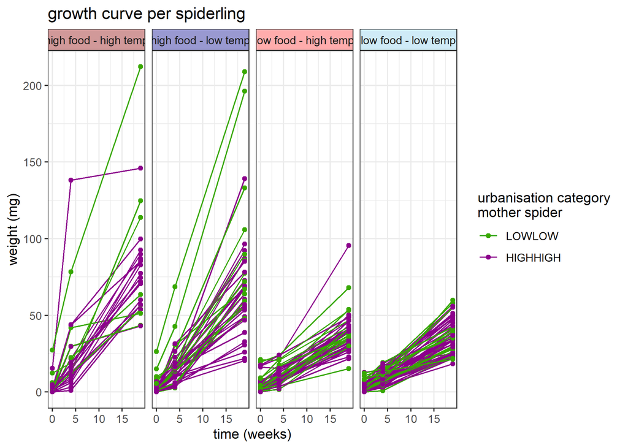

```r
data <- df_weight_limited %>%
  select(spiderlingID, motherID, treatment, urb_cat, weight_start, weight_point1, weight_point2)
colnames(data) <- c("spiderlingID", "motherID", "treatment", "urb_cat", "w0", "w1", "w2")

data_long <- data %>%
  pivot_longer(cols = c("w0", "w1", "w2"),
               names_to = "time",
               names_prefix = "w",
               values_to = "weight")

data_long <- data_long %>%
  mutate(time_numeric = case_when(
    time == "0" ~ 0,
    time == "1" ~ 4,
    time == "2" ~ 19
  ))

data_long <- data_long %>%
  mutate(treatment_name = case_when(
    treatment == "T1" ~ "high food - low temp",
    treatment == "T2" ~ "low food - low temp",
    treatment == "T3" ~ "high food - high temp",
    treatment == "T4" ~ "low food - high temp"
  ))

t_col <- c("darkred", "darkblue", "firebrick1", "skyblue")
data_long$treatment_name <- as.factor(data_long$treatment_name)
p<-ggplot(data_long, aes(x = time_numeric, y = weight, group = spiderlingID, color = urb_cat)) +
  geom_line() +
  geom_point() +
  facet_grid(~treatment_name)+
  labs(title = "growth curve per spiderling",
       x = "time (weeks)",
       y = "weight (mg)",
       color = "urb_cat") +
  scale_colour_manual(values=urb.col2, name="urbanisation category \nmother spider")+
  theme_bw()
p
g <- ggplot_gtable(ggplot_build(p))
stript <- which(grepl('strip-t', g$layout$name))
fills <- scales::alpha(t_col, 0.40)
k <- 1
for (i in stript) {
  j <- which(grepl('rect', g$grobs[[i]]$grobs[[1]]$childrenOrder))
  g$grobs[[i]]$grobs[[1]]$children[[j]]$gp$fill <- fills[k]
  k <- k+1
}
grid::grid.draw(g)
```

using the dataset : df_weight_limited : this contains spiderlings of which both weight point 1 and weight point 2 is noted

```r
df_weight_limited <- df_weight_limited %>%
  mutate(weight_1_corrected=weight_point1-weight_start,
         weight_2_corrected=weight_point2-weight_start)
df_weight <- df_weight %>%
  mutate(weight_1_corrected=weight_point1-weight_start,
         weight_2_corrected=weight_point2-weight_start)

#weight point 1
modA<-glmmTMB(weight_1_corrected ~ treatment* + (1|motherID),data=df_weight_limited, family=gaussian)
summary(modA)
```

```
##  Family: gaussian  ( identity )
## Formula:          weight_1_corrected ~ treatment * +(1 | motherID)
## Data: df_weight_limited
##
##      AIC      BIC   logLik deviance df.resid
##   1334.2   1353.2   -661.1   1322.2      169
##
## Random effects:
##
## Conditional model:
##  Groups   Name        Variance  Std.Dev.
##  motherID (Intercept) 7.985e-07 8.936e-04
##  Residual             1.119e+02 1.058e+01
## Number of obs: 175, groups:  motherID, 25
##
## Dispersion estimate for gaussian family (sigma^2):  112
##
## Conditional model:
##             Estimate Std. Error z value Pr(>|z|)
## (Intercept)   13.396      1.652   8.109  5.1e-16 ***
## treatmentT2   -6.273      2.129  -2.946 0.003218 **
## treatmentT3    9.193      2.719   3.381 0.000721 ***
## treatmentT4   -6.899      2.250  -3.067 0.002162 **
## ---
## Signif. codes:  0 '***' 0.001 '**' 0.01 '*' 0.05 '.' 0.1 ' ' 1
```

```r
Anova(modA, type="3")
```

```
## Analysis of Deviance Table (Type III Wald chisquare tests)
##
## Response: weight_1_corrected
##              Chisq Df Pr(>Chisq)
## (Intercept) 65.758  1  5.098e-16 ***
## treatment   47.609  3  2.579e-10 ***
## ---
## Signif. codes:  0 '***' 0.001 '**' 0.01 '*' 0.05 '.' 0.1 ' ' 1
```

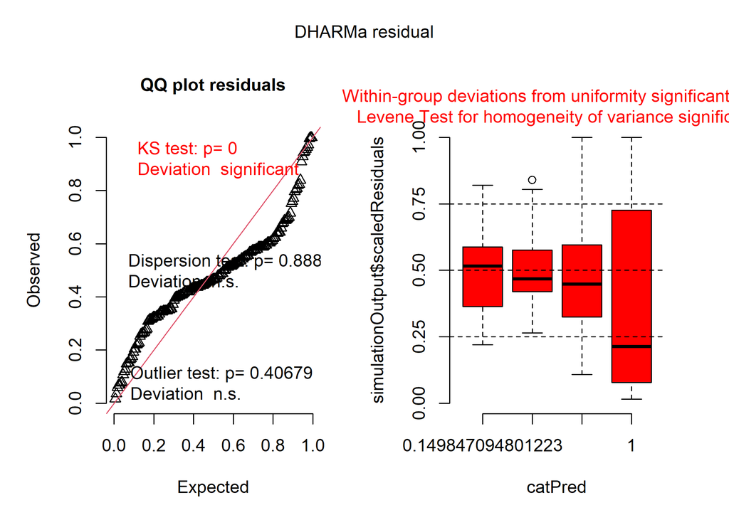

```r
plot(simulateResiduals(modA))
```

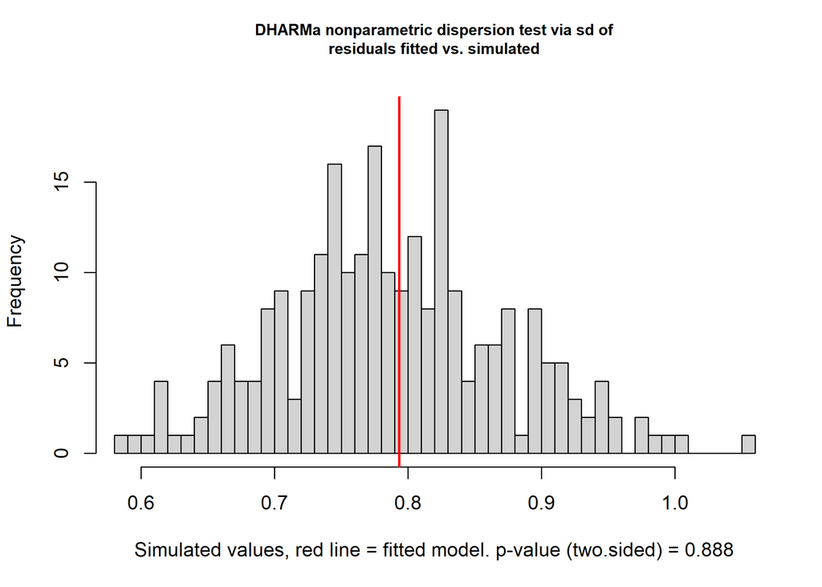

```
##
##  DHARMa nonparametric dispersion test via sd of residuals fitted vs.
##  simulated
##
## data:  simulationOutput
## dispersion = 1.0067, p-value = 0.888
## alternative hypothesis: two.sided
```

```r
testDispersion(simulateResiduals(modA))
```

```r
testZeroInflation(simulateResiduals(modA))
```

```
##
##  DHARMa zero-inflation test via comparison to expected zeros with
##  simulation under H0 = fitted model
##
## data:  simulationOutput
## ratioObsSim = NaN, p-value = 1
## alternative hypothesis: two.sided
```

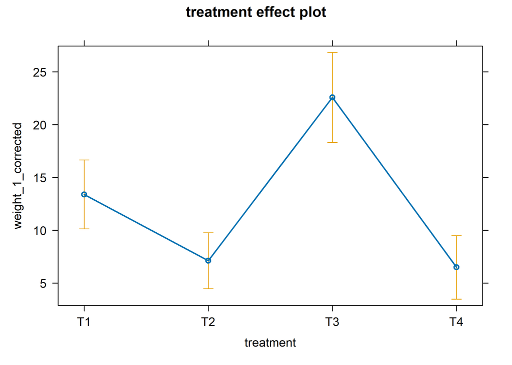

```r
plot(allEffects(modA))
```

```r
contrast(emmeans(modA, specs=~treatment), method="pairwise")
```

```
##  contrast estimate   SE  df t.ratio p.value
##  T1 - T2     6.273 2.13 169   2.946  0.0191
##  T1 - T3    -9.193 2.72 169  -3.381  0.0049
##  T1 - T4     6.899 2.25 169   3.067  0.0133
##  T2 - T3   -15.466 2.54 169  -6.082  <.0001
##  T2 - T4     0.626 2.03 169   0.308  0.9898
##  T3 - T4    16.092 2.64 169   6.085  <.0001
##
## P value adjustment: tukey method for comparing a family of 4 estimates
```

this result after 4 weeks in treatment used the corrected weight point 1 (weight point 1 - start weight when entering the treatment) Treatment is singificant

```r
modA_comp <- contrast(emmeans(modA, specs=~treatment), method="pairwise") |> as_tibble()
modA_comp %>% knitr::kable()
```

| contrast | estimate | SE | df | t.ratio | p.value |
| --- | --- | --- | --- | --- | --- |
| T1 - T2 | 6.2730512 | 2.129289 | 169 | 2.9460780 | 0.0190659 |
| T1 - T3 | -9.1927506 | 2.718710 | 169 | -3.3812914 | 0.0049228 |
| T1 - T4 | 6.8991337 | 2.249501 | 169 | 3.0669617 | 0.0133163 |
| T2 - T3 | -15.4658017 | 2.543030 | 169 | -6.0816431 | 0.0000000 |
| T2 - T4 | 0.6260825 | 2.033685 | 169 | 0.3078562 | 0.9898463 |
| T3 - T4 | 16.0918842 | 2.644501 | 169 | 6.0850359 | 0.0000000 |

T2 and T4 not significantly different

this is the result after 19 weeks in treatment

```r
#weight point 2
modB<-glmmTMB(weight_2_corrected ~ treatment*urb_cat + (1|motherID),data=df_weight_limited, family=gaussian)
summary(modB)
```

```
##  Family: gaussian  ( identity )
## Formula:          weight_2_corrected ~ treatment * urb_cat + (1 | motherID)
## Data: df_weight_limited
##
##      AIC      BIC   logLik deviance df.resid
##   1569.9   1601.5   -774.9   1549.9      165
##
## Random effects:
##
## Conditional model:
##  Groups   Name        Variance Std.Dev.
##  motherID (Intercept)  57.94    7.612
##  Residual             373.71   19.332
## Number of obs: 175, groups:  motherID, 25
##
## Dispersion estimate for gaussian family (sigma^2):  374
##
## Conditional model:
##                             Estimate Std. Error z value Pr(>|z|)
## (Intercept)                   89.288      5.607  15.925  < 2e-16 ***
## treatmentT2                  -60.153      6.885  -8.737  < 2e-16 ***
## treatmentT3                   -5.367      9.132  -0.588 0.556703
## treatmentT4                  -59.667      7.144  -8.352  < 2e-16 ***
## urb_catHIGHHIGH              -29.456      7.217  -4.081 4.48e-05 ***
## treatmentT2:urb_catHIGHHIGH   32.743      8.449   3.875 0.000106 ***
## treatmentT3:urb_catHIGHHIGH   20.036     11.027   1.817 0.069223 .
## treatmentT4:urb_catHIGHHIGH   33.778      8.833   3.824 0.000131 ***
## ---
## Signif. codes:  0 '***' 0.001 '**' 0.01 '*' 0.05 '.' 0.1 ' ' 1
```

```r
Anova(modB, type="3")
```

```
## Analysis of Deviance Table (Type III Wald chisquare tests)
##
## Response: weight_2_corrected
##                     Chisq Df Pr(>Chisq)
## (Intercept)       253.592  1  < 2.2e-16 ***
## treatment         117.601  3  < 2.2e-16 ***
## urb_cat            16.656  1   4.48e-05 ***
## treatment:urb_cat  19.241  3  0.0002437 ***
## ---
## Signif. codes:  0 '***' 0.001 '**' 0.01 '*' 0.05 '.' 0.1 ' ' 1
```

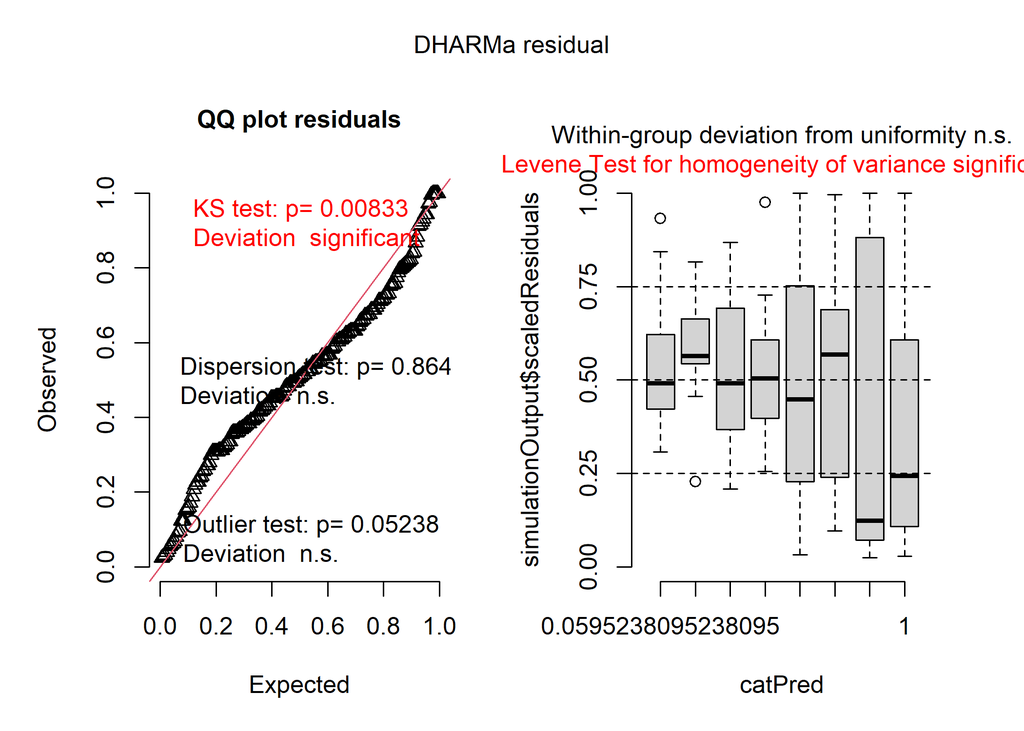

```r
plot(simulateResiduals(modB))
```

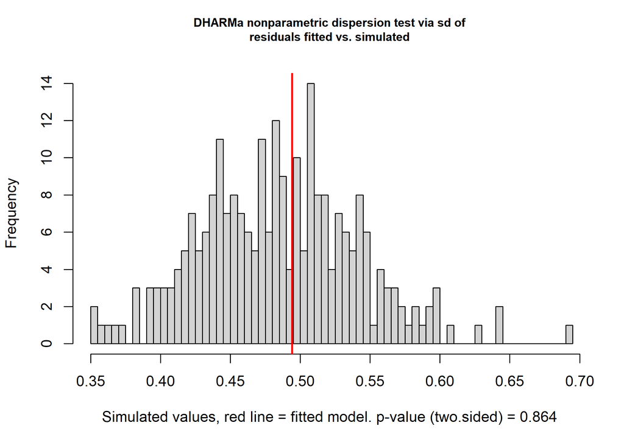

```
##
##  DHARMa nonparametric dispersion test via sd of residuals fitted vs.
##  simulated
##
## data:  simulationOutput
## dispersion = 1.0202, p-value = 0.864
## alternative hypothesis: two.sided
```

```r
testDispersion(simulateResiduals(modB))
```

```r
testZeroInflation(simulateResiduals(modB))
```

```
##
##  DHARMa zero-inflation test via comparison to expected zeros with
##  simulation under H0 = fitted model
##
## data:  simulationOutput
## ratioObsSim = NaN, p-value = 1
## alternative hypothesis: two.sided
```

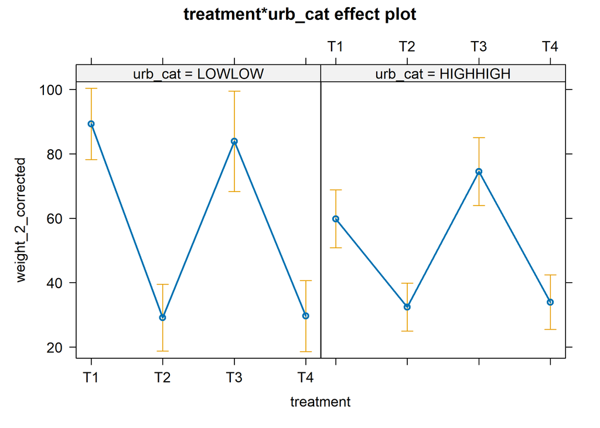

```r
plot(allEffects(modB))
```

```r
contrast(emmeans(modB, specs=~treatment*urb_cat), method="pairwise")
```

```
##  contrast                  estimate   SE  df t.ratio p.value
##  T1 LOWLOW - T2 LOWLOW       60.153 6.89 165   8.737  <.0001
##  T1 LOWLOW - T3 LOWLOW        5.367 9.13 165   0.588  0.9990
##  T1 LOWLOW - T4 LOWLOW       59.667 7.14 165   8.352  <.0001
##  T1 LOWLOW - T1 HIGHHIGH     29.456 7.22 165   4.081  0.0018
##  T1 LOWLOW - T2 HIGHHIGH     56.865 6.74 165   8.435  <.0001
##  T1 LOWLOW - T3 HIGHHIGH     14.787 7.75 165   1.909  0.5469
##  T1 LOWLOW - T4 HIGHHIGH     55.345 7.04 165   7.861  <.0001
##  T2 LOWLOW - T3 LOWLOW      -54.785 8.80 165  -6.226  <.0001
##  T2 LOWLOW - T4 LOWLOW       -0.485 6.74 165  -0.072  1.0000
##  T2 LOWLOW - T1 HIGHHIGH    -30.697 6.94 165  -4.423  0.0005
##  T2 LOWLOW - T2 HIGHHIGH     -3.287 6.41 165  -0.513  0.9996
##  T2 LOWLOW - T3 HIGHHIGH    -45.366 7.47 165  -6.070  <.0001
##  T2 LOWLOW - T4 HIGHHIGH     -4.807 6.73 165  -0.714  0.9965
##  T3 LOWLOW - T4 LOWLOW       54.300 8.86 165   6.131  <.0001
##  T3 LOWLOW - T1 HIGHHIGH     24.089 9.11 165   2.645  0.1477
##  T3 LOWLOW - T2 HIGHHIGH     51.498 8.71 165   5.915  <.0001
##  T3 LOWLOW - T3 HIGHHIGH      9.419 9.52 165   0.990  0.9754
##  T3 LOWLOW - T4 HIGHHIGH     49.978 8.94 165   5.589  <.0001
##  T4 LOWLOW - T1 HIGHHIGH    -30.212 7.18 165  -4.207  0.0011
##  T4 LOWLOW - T2 HIGHHIGH     -2.802 6.64 165  -0.422  0.9999
##  T4 LOWLOW - T3 HIGHHIGH    -44.881 7.68 165  -5.842  <.0001
##  T4 LOWLOW - T4 HIGHHIGH     -4.322 6.95 165  -0.622  0.9985
##  T1 HIGHHIGH - T2 HIGHHIGH   27.410 4.94 165   5.551  <.0001
##  T1 HIGHHIGH - T3 HIGHHIGH  -14.669 6.21 165  -2.363  0.2665
##  T1 HIGHHIGH - T4 HIGHHIGH   25.890 5.27 165   4.917  0.0001
##  T2 HIGHHIGH - T3 HIGHHIGH  -42.079 5.71 165  -7.368  <.0001
##  T2 HIGHHIGH - T4 HIGHHIGH   -1.520 4.60 165  -0.331  1.0000
##  T3 HIGHHIGH - T4 HIGHHIGH   40.559 6.03 165   6.730  <.0001
##
## P value adjustment: tukey method for comparing a family of 8 estimates
```

```r
modB_comp <- contrast(emmeans(modB, specs=~treatment*urb_cat), method="pairwise") |> as_tibble()
modB_comp %>% knitr::kable()
```

| contrast | estimate | SE | df | t.ratio | p.value |
| --- | --- | --- | --- | --- | --- |
| T1 LOWLOW - T2 LOWLOW | 60.1525651 | 6.885029 | 165 | 8.7367188 | 0.0000000 |
| T1 LOWLOW - T3 LOWLOW | 5.3672363 | 9.131907 | 165 | 0.5877454 | 0.9989859 |
| T1 LOWLOW - T4 LOWLOW | 59.6673380 | 7.143745 | 165 | 8.3523897 | 0.0000000 |
| T1 LOWLOW - T1 HIGHHIGH | 29.4557644 | 7.217388 | 165 | 4.0812225 | 0.0017550 |
| T1 LOWLOW - T2 HIGHHIGH | 56.8653548 | 6.741209 | 165 | 8.4354834 | 0.0000000 |
| T1 LOWLOW - T3 HIGHHIGH | 14.7865284 | 7.746687 | 165 | 1.9087551 | 0.5469323 |
| T1 LOWLOW - T4 HIGHHIGH | 55.3452901 | 7.040803 | 165 | 7.8606506 | 0.0000000 |
| T2 LOWLOW - T3 LOWLOW | -54.7853288 | 8.799878 | 165 | -6.2256918 | 0.0000001 |
| T2 LOWLOW - T4 LOWLOW | -0.4852271 | 6.740795 | 165 | -0.0719837 | 1.0000000 |
| T2 LOWLOW - T1 HIGHHIGH | -30.6968007 | 6.941030 | 165 | -4.4225136 | 0.0004609 |
| T2 LOWLOW - T2 HIGHHIGH | -3.2872104 | 6.413881 | 165 | -0.5125150 | 0.9995866 |
| T2 LOWLOW - T3 HIGHHIGH | -45.3660367 | 7.473654 | 165 | -6.0701279 | 0.0000002 |
| T2 LOWLOW - T4 HIGHHIGH | -4.8072751 | 6.729644 | 165 | -0.7143432 | 0.9964803 |
| T3 LOWLOW - T4 LOWLOW | 54.3001017 | 8.857255 | 165 | 6.1305787 | 0.0000002 |
| T3 LOWLOW - T1 HIGHHIGH | 24.0885281 | 9.108137 | 165 | 2.6447263 | 0.1477357 |
| T3 LOWLOW - T2 HIGHHIGH | 51.4981184 | 8.706834 | 165 | 5.9146782 | 0.0000005 |
| T3 LOWLOW - T3 HIGHHIGH | 9.4192921 | 9.516739 | 165 | 0.9897604 | 0.9753536 |
| T3 LOWLOW - T4 HIGHHIGH | 49.9780537 | 8.942319 | 165 | 5.5889363 | 0.0000026 |
| T4 LOWLOW - T1 HIGHHIGH | -30.2115736 | 7.181281 | 165 | -4.2069895 | 0.0010840 |
| T4 LOWLOW - T2 HIGHHIGH | -2.8019833 | 6.644517 | 165 | -0.4216986 | 0.9998875 |
| T4 LOWLOW - T3 HIGHHIGH | -44.8808096 | 7.681991 | 165 | -5.8423405 | 0.0000007 |
| T4 LOWLOW - T4 HIGHHIGH | -4.3220480 | 6.951289 | 165 | -0.6217621 | 0.9985414 |
| T1 HIGHHIGH - T2 HIGHHIGH | 27.4095903 | 4.937423 | 165 | 5.5513963 | 0.0000031 |
| T1 HIGHHIGH - T3 HIGHHIGH | -14.6692360 | 6.206707 | 165 | -2.3634491 | 0.2665164 |
| T1 HIGHHIGH - T4 HIGHHIGH | 25.8895256 | 5.265777 | 165 | 4.9165632 | 0.0000570 |
| T2 HIGHHIGH - T3 HIGHHIGH | -42.0788264 | 5.711324 | 165 | -7.3676128 | 0.0000000 |
| T2 HIGHHIGH - T4 HIGHHIGH | -1.5200647 | 4.596855 | 165 | -0.3306749 | 0.9999784 |
| T3 HIGHHIGH - T4 HIGHHIGH | 40.5587617 | 6.026810 | 165 | 6.7297228 | 0.0000000 |

treatment*urb_cat => significant , table shows the pairwise comparisons

includes 414 spiderlings

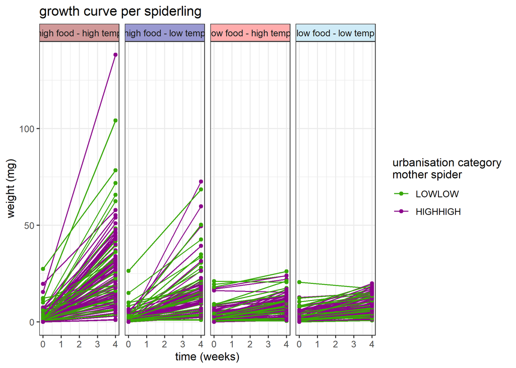

```r
data <- df_weight %>%
  select(spiderlingID, motherID, treatment, urb_cat, weight_start, weight_point1)
colnames(data) <- c("spiderlingID", "motherID", "treatment", "urb_cat", "w0", "w1")

data_long <- data %>%
  pivot_longer(cols = c("w0", "w1"),
               names_to = "time",
               names_prefix = "w",
               values_to = "weight")

data_long <- data_long %>%
  mutate(time_numeric = case_when(
    time == "0" ~ 0,
    time == "1" ~ 4,
  ))

data_long <- data_long %>%
  mutate(treatment_name = case_when(
    treatment == "T1" ~ "high food - low temp",
    treatment == "T2" ~ "low food - low temp",
    treatment == "T3" ~ "high food - high temp",
    treatment == "T4" ~ "low food - high temp"
  ))
t_col <- c("darkred", "darkblue", "firebrick1", "skyblue")
data_long$treatment_name <- as.factor(data_long$treatment_name)

p<-ggplot(data_long, aes(x = time_numeric, y = weight, group = spiderlingID, color = urb_cat)) +
  geom_line() +
  geom_point() +
  facet_grid(~treatment_name)+
  labs(title = "growth curve per spiderling",
       x = "time (weeks)",
       y = "weight (mg)",
       color = "urb_cat") +
  scale_colour_manual(values=urb.col2, name="urbanisation category \nmother spider")+
  theme_bw()
p
g <- ggplot_gtable(ggplot_build(p))
stript <- which(grepl('strip-t', g$layout$name))
fills <- scales::alpha(t_col, 0.40)
k <- 1
for (i in stript) {
  j <- which(grepl('rect', g$grobs[[i]]$grobs[[1]]$childrenOrder))
  g$grobs[[i]]$grobs[[1]]$children[[j]]$gp$fill <- fills[k]
  k <- k+1
}
grid::grid.draw(g)
```

statistics now for the full dataset

```r
modA<-glmmTMB(weight_1_corrected ~ treatment*urb_cat +(1|motherID),data=df_weight, family=gaussian)
summary(modA)
```

```
##  Family: gaussian  ( identity )
## Formula:          weight_1_corrected ~ treatment * urb_cat + (1 | motherID)
## Data: df_weight
##
##      AIC      BIC   logLik deviance df.resid
##   3213.7   3254.0  -1596.9   3193.7      404
##
## Random effects:
##
## Conditional model:
##  Groups   Name        Variance Std.Dev.
##  motherID (Intercept)  10.25    3.202
##  Residual             124.94   11.178
## Number of obs: 414, groups:  motherID, 27
##
## Dispersion estimate for gaussian family (sigma^2):  125
##
## Conditional model:
##                             Estimate Std. Error z value Pr(>|z|)
## (Intercept)                 14.04818    1.95336   7.192 6.39e-13 ***
## treatmentT2                 -8.10195    2.50861  -3.230  0.00124 **
## treatmentT3                 10.11010    2.48977   4.061 4.89e-05 ***
## treatmentT4                 -7.70046    2.56117  -3.007  0.00264 **
## urb_catHIGHHIGH              0.60696    2.68414   0.226  0.82110
## treatmentT2:urb_catHIGHHIGH  0.04794    3.27635   0.015  0.98833
## treatmentT3:urb_catHIGHHIGH -1.43899    3.22314  -0.446  0.65527
## treatmentT4:urb_catHIGHHIGH -1.20629    3.32400  -0.363  0.71668
## ---
## Signif. codes:  0 '***' 0.001 '**' 0.01 '*' 0.05 '.' 0.1 ' ' 1
```

```r
Anova(modA, type="3")
```

```
## Analysis of Deviance Table (Type III Wald chisquare tests)
##
## Response: weight_1_corrected
##                     Chisq Df Pr(>Chisq)
## (Intercept)       51.7221  1  6.394e-13 ***
## treatment         68.1435  3  1.066e-14 ***
## urb_cat            0.0511  1     0.8211
## treatment:urb_cat  0.3548  3     0.9494
## ---
## Signif. codes:  0 '***' 0.001 '**' 0.01 '*' 0.05 '.' 0.1 ' ' 1
```

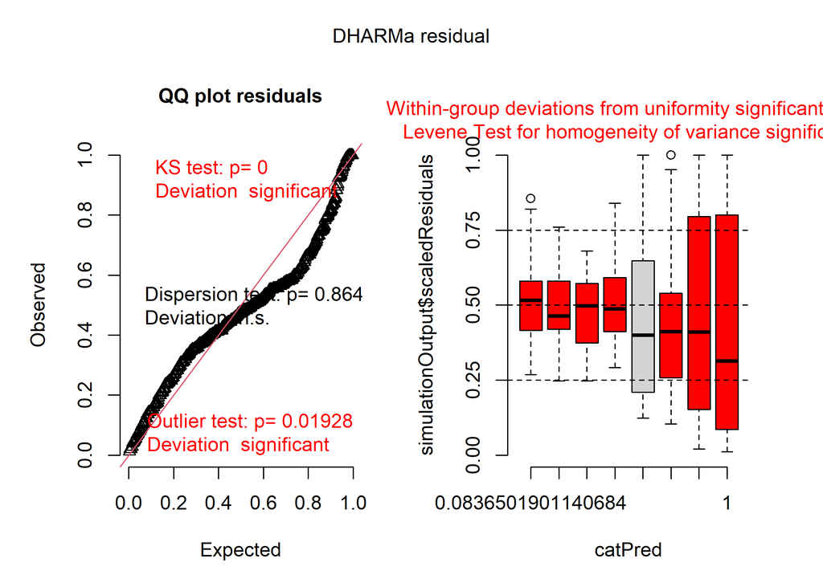

```r
plot(simulateResiduals(modA))
```

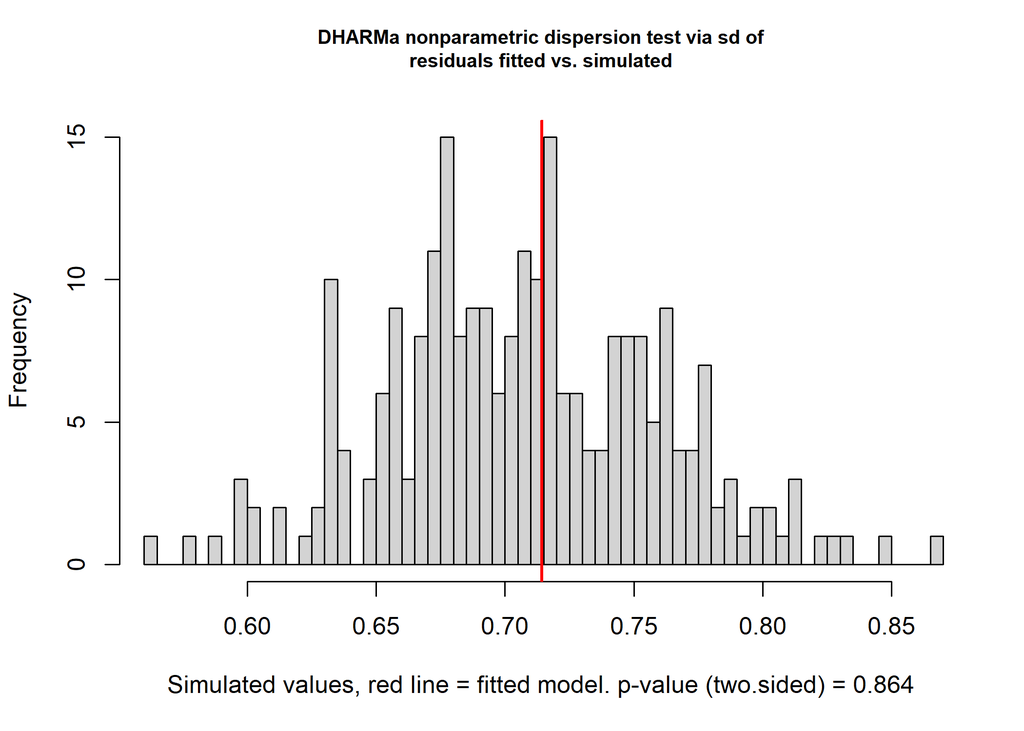

```
##
##  DHARMa nonparametric dispersion test via sd of residuals fitted vs.
##  simulated
##
## data:  simulationOutput
## dispersion = 1.0096, p-value = 0.864
## alternative hypothesis: two.sided
```

```r
testDispersion(simulateResiduals(modA))
```

```r
testZeroInflation(simulateResiduals(modA))
```

```
##
##  DHARMa zero-inflation test via comparison to expected zeros with
##  simulation under H0 = fitted model
##
## data:  simulationOutput
## ratioObsSim = NaN, p-value = 1
## alternative hypothesis: two.sided
```

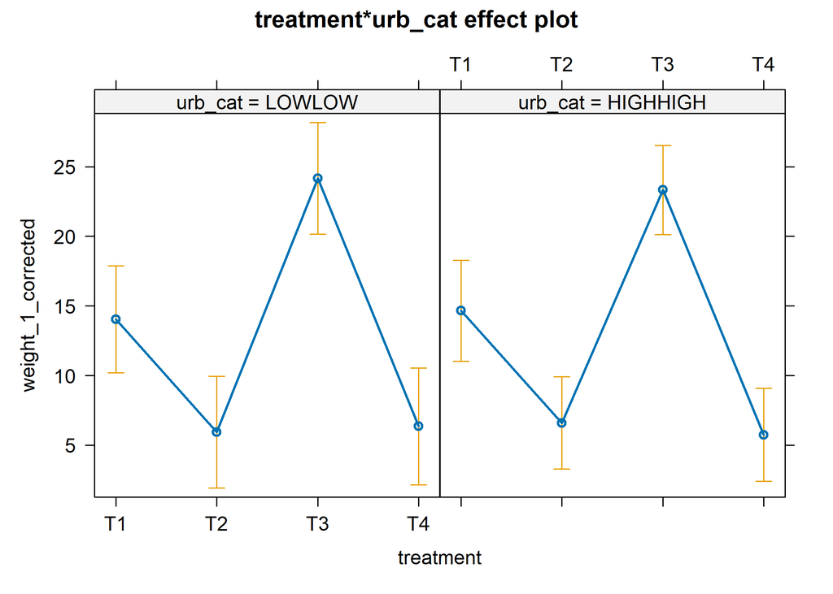

```r
plot(allEffects(modA))
```

```r
contrast(emmeans(modA, specs=~treatment), method="pairwise")
```

```
##  contrast estimate   SE  df t.ratio p.value
##  T1 - T2     8.078 1.64 404   4.932  <.0001
##  T1 - T3    -9.391 1.61 404  -5.825  <.0001
##  T1 - T4     8.304 1.66 404   5.001  <.0001
##  T2 - T3   -17.469 1.58 404 -11.042  <.0001
##  T2 - T4     0.226 1.63 404   0.138  0.9991
##  T3 - T4    17.694 1.60 404  11.029  <.0001
##
## Results are averaged over the levels of: urb_cat
## P value adjustment: tukey method for comparing a family of 4 estimates
```

with full dataset same result for weigth after 4 weeks: all treatments are significantly different except for T2 and T4 **highest increase in weight under treatment: high food - high temperature**

**weight spiderslings presented after 4 and 19 weeks of treatment** **visualised for the urbanisation context of the mother spider and treatments**

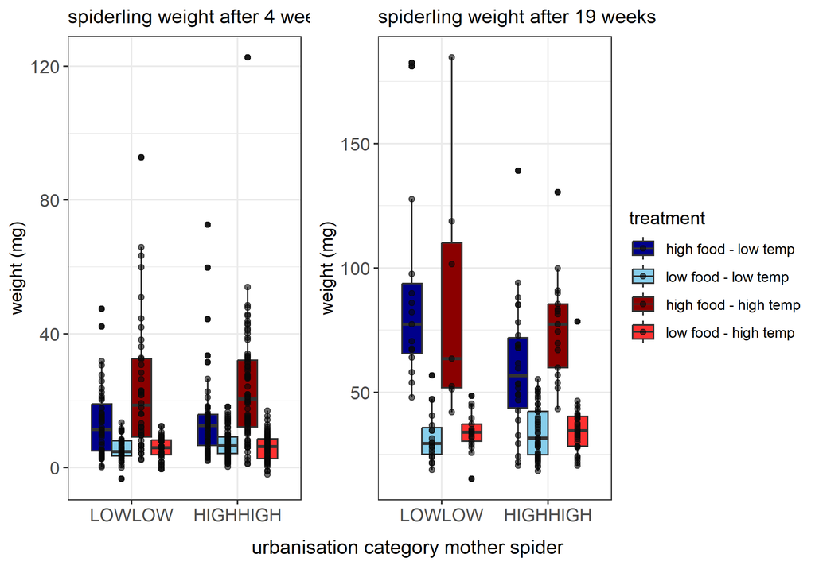

```r
weight1<-ggplot(df_weight, aes(urb_cat, weight_1_corrected, fill=treatment)) +
  geom_boxplot(position=position_dodge(width=0.75))+
  geom_jitter(position=position_dodge(width=0.75), alpha=0.6, size=1.5, color="gray3")+
  scale_fill_manual(values = c("darkblue", "skyblue", "darkred", "firebrick1"), name="treatment", labels=treatment_vec)+
  ylab("weight (mg)")+
  xlab("")+
  ggtitle("spiderling weight after 4 weeks")+
  theme_bw()+
  theme(axis.text = element_text(size=rel(1)), axis.title=element_text(size=rel(1)), plot.title=element_text(size=rel(1.1)))

weight2<-ggplot(df_weight, aes(urb_cat, weight_2_corrected, fill=treatment)) +
  geom_boxplot(position=position_dodge(width=0.75))+
  geom_jitter(position=position_dodge(width=0.75), alpha=0.6, size=1.5, color="gray3")+
  scale_fill_manual(values = c("darkblue", "skyblue", "darkred", "firebrick1"), name="treatment", labels=treatment_vec) +
  ylab("weight (mg)")+
  xlab("")+
  ggtitle("spiderling weight after 19 weeks")+
  theme_bw()+
  theme(axis.text = element_text(size=rel(1)), axis.title=element_text(size=rel(1)), plot.title=element_text(size=rel(1.1)))

fig<-ggarrange(weight1, weight2, common.legend=T, legend="right")
annotate_figure(fig, bottom=text_grob("urbanisation category mother spider", vjust=-1))
```

**weight spiderslings presented after 4 and 19 weeks of treatment** **visualised for the urbanisation context of the mother spider and treatments**

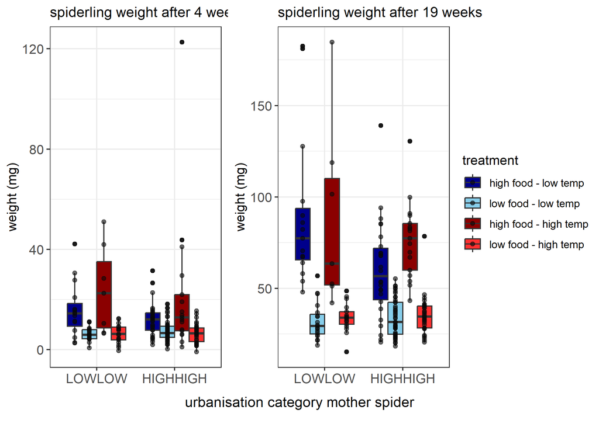

```r
weight1<-ggplot(df_weight_limited, aes(urb_cat, weight_1_corrected, fill=treatment)) +
  geom_boxplot(position=position_dodge(width=0.75))+
  geom_jitter(position=position_dodge(width=0.75), alpha=0.6, size=1.5, color="gray3")+
  scale_fill_manual(values = c("darkblue", "skyblue", "darkred", "firebrick1"), name="treatment", labels=treatment_vec)+
  ylab("weight (mg)")+
  xlab("")+
  ggtitle("spiderling weight after 4 weeks")+
  theme_bw()+
  theme(axis.text = element_text(size=rel(1)), axis.title=element_text(size=rel(1)), plot.title=element_text(size=rel(1.1)))

weight2<-ggplot(df_weight_limited, aes(urb_cat, weight_2_corrected, fill=treatment)) +
  geom_boxplot(position=position_dodge(width=0.75))+
  geom_jitter(position=position_dodge(width=0.75), alpha=0.6, size=1.5, color="gray3")+
  scale_fill_manual(values = c("darkblue", "skyblue", "darkred", "firebrick1"), name="treatment", labels=treatment_vec) +
  ylab("weight (mg)")+
  xlab("")+
  ggtitle("spiderling weight after 19 weeks")+
  theme_bw()+
  theme(axis.text = element_text(size=rel(1)), axis.title=element_text(size=rel(1)), plot.title=element_text(size=rel(1.1)))

fig<-ggarrange(weight1, weight2, common.legend=T, legend="right")
annotate_figure(fig, bottom=text_grob("urbanisation category mother spider", vjust=-1))
```

** per mother **

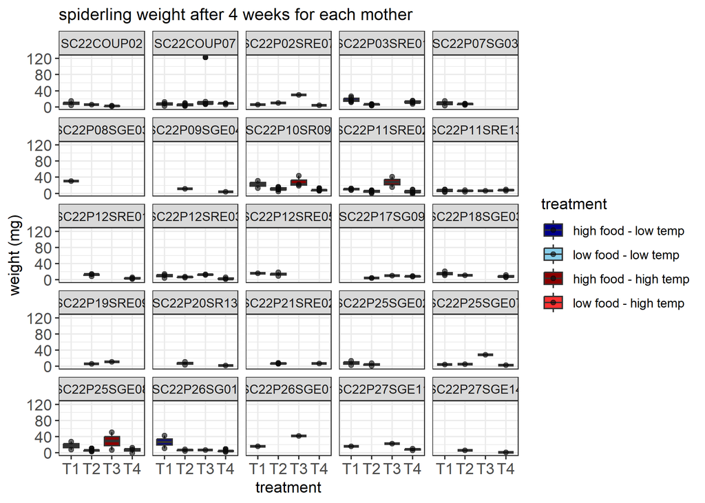

```r
weight1<-ggplot(df_weight_limited, aes(treatment, weight_1_corrected, fill=treatment)) +
  geom_boxplot(position=position_dodge(width=0.75))+
  geom_jitter(position=position_dodge(width=0.75), alpha=0.6, size=1.5, color="gray3")+
  scale_fill_manual(values = c("darkblue", "skyblue", "darkred", "firebrick1"), name="treatment", labels=treatment_vec)+
  ylab("weight (mg)")+
  xlab("treatment")+
  ggtitle("spiderling weight after 4 weeks for each mother")+
  theme_bw()+
  facet_wrap(~motherID)+
  theme(axis.text = element_text(size=rel(1)), axis.title=element_text(size=rel(1)), plot.title=element_text(size=rel(1.1)))
weight1
```

```r
weight2<-ggplot(df_weight_limited, aes(treatment, weight_2_corrected, fill=treatment)) +
  geom_boxplot(position=position_dodge(width=0.75))+
  geom_jitter(position=position_dodge(width=0.75), alpha=0.6, size=1.5, color="gray3")+
  scale_fill_manual(values = c("darkblue", "skyblue", "darkred", "firebrick1"), name="treatment", labels=treatment_vec) +
  ylab("weight (mg)")+
  xlab("urbanisation category")+
  ggtitle("spiderling weight after 19 weeks for each mother")+
  theme_bw()+
  facet_wrap(~motherID)+
  theme(axis.text = element_text(size=rel(1)), axis.title=element_text(size=rel(1)), plot.title=element_text(size=rel(1.1)))
```

**extra per urbanisation context other type of graphic**

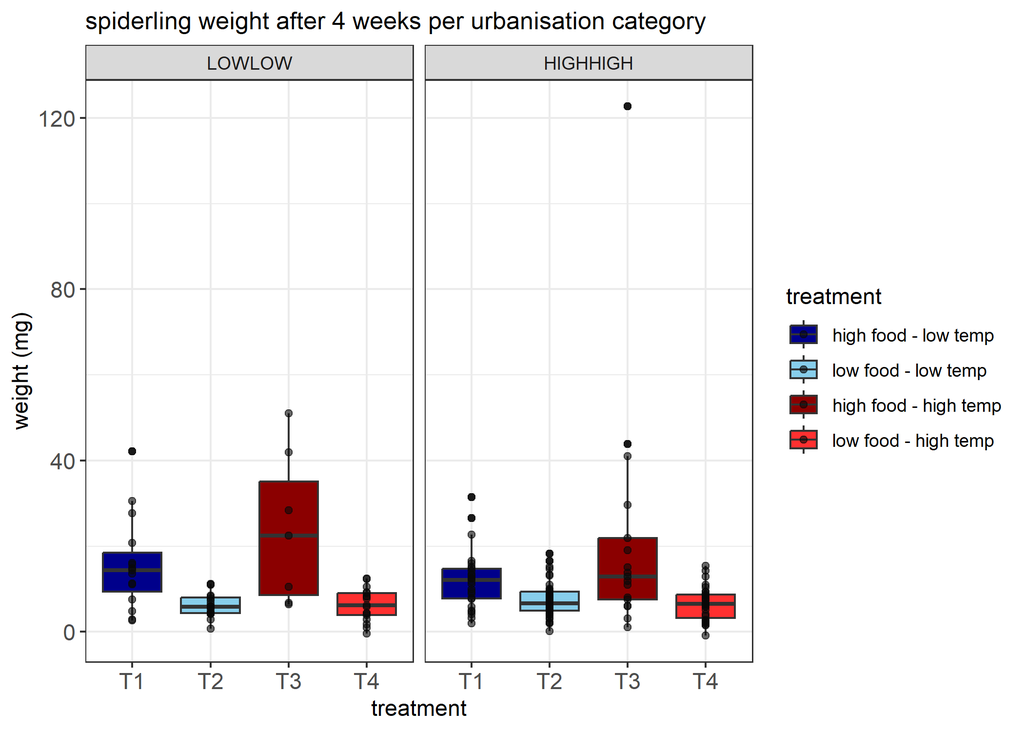

```r
weight1<-ggplot(df_weight_limited, aes(treatment, weight_1_corrected, fill=treatment)) +
  geom_boxplot(position=position_dodge(width=0.75))+
  geom_jitter(position=position_dodge(width=0.75), alpha=0.6, size=1.5, color="gray3")+
  scale_fill_manual(values = c("darkblue", "skyblue", "darkred", "firebrick1"), name="treatment", labels=treatment_vec)+
  ylab("weight (mg)")+
  xlab("treatment")+
  ggtitle("spiderling weight after 4 weeks per urbanisation category")+
  theme_bw()+
  facet_wrap(~urb_cat)+
  theme(axis.text = element_text(size=rel(1)), axis.title=element_text(size=rel(1)), plot.title=element_text(size=rel(1.1)))
weight1
```

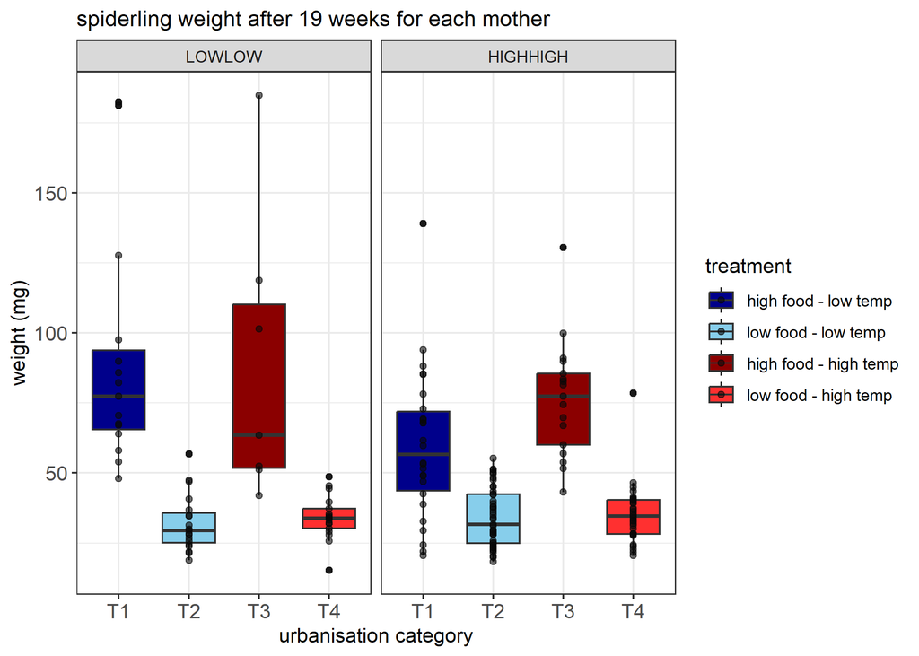

```r
weight2<-ggplot(df_weight_limited, aes(treatment, weight_2_corrected, fill=treatment)) +
  geom_boxplot(position=position_dodge(width=0.75))+
  geom_jitter(position=position_dodge(width=0.75), alpha=0.6, size=1.5, color="gray3")+
  scale_fill_manual(values = c("darkblue", "skyblue", "darkred", "firebrick1"), name="treatment", labels=treatment_vec) +
  ylab("weight (mg)")+
  xlab("urbanisation category")+
  ggtitle("spiderling weight after 19 weeks for each mother")+
  theme_bw()+
  facet_wrap(~urb_cat)+
  theme(axis.text = element_text(size=rel(1)), axis.title=element_text(size=rel(1)), plot.title=element_text(size=rel(1.1)))
weight2
```

## maturity - dead

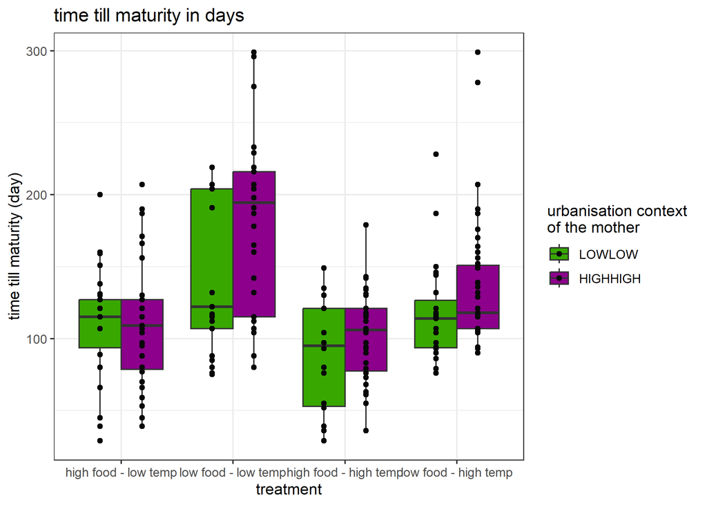

```r
graph1<-ggplot(df_maturity, aes(x = treatment, y = time_till_maturity, fill = urb_cat)) +
  geom_boxplot(position=position_dodge(width=0.75)) +
  geom_point(position=position_dodge(width=0.75), colour="gray3")+
  scale_fill_manual(values=urb.col2, name="urbanisation context \nof the mother")+
  theme_bw()+
  #theme(legend.position = "none",
  labs(x = "treatment",
       y = "time till maturity (day)",
       title = "time till maturity in days")+
  scale_x_discrete(labels=treatment_vec)
graph1
```

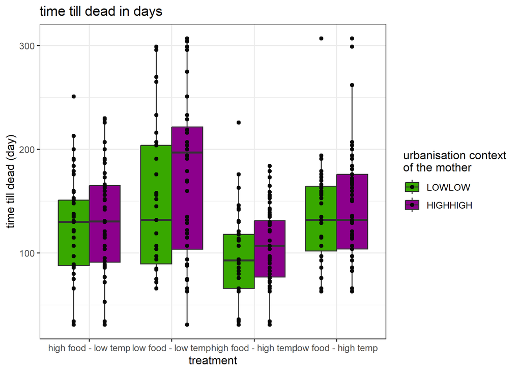

```r
graph2 <-ggplot(df_dead, aes(x = treatment, y = time_till_dead, fill = urb_cat)) +
  geom_boxplot(position=position_dodge(width=0.75)) +
  geom_point(position=position_dodge(width=0.75), colour="gray3")+
  scale_fill_manual(values=urb.col2, name="urbanisation context \nof the mother")+
  theme_bw()+
  #theme(legend.position = "none",
  labs(x = "treatment",
       y = "time till dead (day)",
       title = "time till dead in days")+
  scale_x_discrete(labels=treatment_vec)
graph2
```

```r
modC<-glmmTMB(time_till_maturity ~ treatment*urb_cat + (1|motherID),data=df_maturity, family=gaussian)
summary(modC)
```

```
##  Family: gaussian  ( identity )
## Formula:          time_till_maturity ~ treatment * urb_cat + (1 | motherID)
## Data: df_maturity
##
##      AIC      BIC   logLik deviance df.resid
##   2916.3   2952.6  -1448.1   2896.3      269
##
## Random effects:
##
## Conditional model:
##  Groups   Name        Variance  Std.Dev.
##  motherID (Intercept) 2.211e-05  0.004702
##  Residual             1.888e+03 43.446157
## Number of obs: 279, groups:  motherID, 26
##
## Dispersion estimate for gaussian family (sigma^2): 1.89e+03
##
## Conditional model:
##                             Estimate Std. Error z value Pr(>|z|)
## (Intercept)                  112.706      7.451  15.126  < 2e-16 ***
## treatmentT2                   29.373     11.446   2.566  0.01028 *
## treatmentT3                  -24.928     12.664  -1.968  0.04902 *
## treatmentT4                    3.739     11.199   0.334  0.73851
## urb_catHIGHHIGH               -5.809     10.194  -0.570  0.56880
## treatmentT2:urb_catHIGHHIGH   40.375     14.790   2.730  0.00633 **
## treatmentT3:urb_catHIGHHIGH   18.566     15.896   1.168  0.24282
## treatmentT4:urb_catHIGHHIGH   24.497     14.689   1.668  0.09537 .
## ---
## Signif. codes:  0 '***' 0.001 '**' 0.01 '*' 0.05 '.' 0.1 ' ' 1
```

```r
Anova(modC, type="3")
```

```
## Analysis of Deviance Table (Type III Wald chisquare tests)
##
## Response: time_till_maturity
##                      Chisq Df Pr(>Chisq)
## (Intercept)       228.8073  1  < 2.2e-16 ***
## treatment          16.7918  3  0.0007799 ***
## urb_cat             0.3247  1  0.5688022
## treatment:urb_cat   7.6523  3  0.0537716 .
## ---
## Signif. codes:  0 '***' 0.001 '**' 0.01 '*' 0.05 '.' 0.1 ' ' 1
```

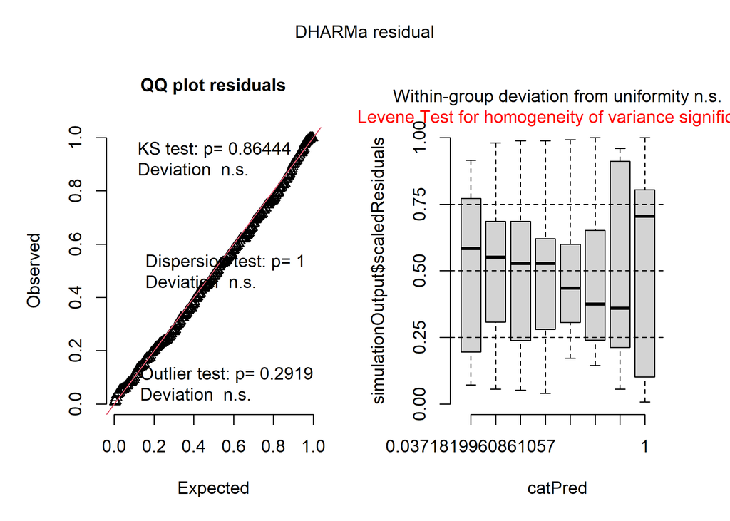

```r
plot(simulateResiduals(modC))
```

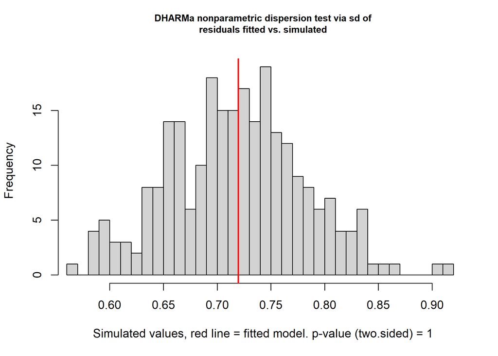

```
##
##  DHARMa nonparametric dispersion test via sd of residuals fitted vs.
##  simulated
##
## data:  simulationOutput
## dispersion = 1.0019, p-value = 1
## alternative hypothesis: two.sided
```

```r
testDispersion(simulateResiduals(modC))
```

```r
testZeroInflation(simulateResiduals(modC))
```

```
##
##  DHARMa zero-inflation test via comparison to expected zeros with
##  simulation under H0 = fitted model
##
## data:  simulationOutput
## ratioObsSim = NaN, p-value = 1
## alternative hypothesis: two.sided
```

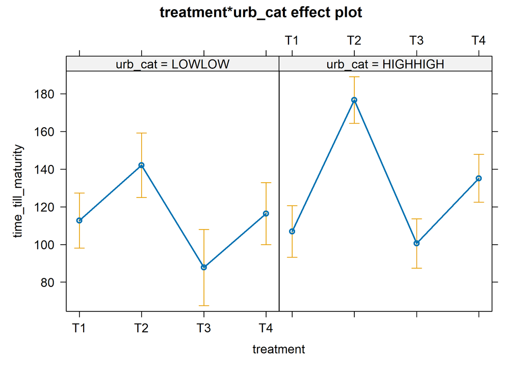

```r
plot(allEffects(modC))
```

```r
contrast(emmeans(modC, specs=~treatment*urb_cat), method="pairwise")
```

```
##  contrast                  estimate    SE  df t.ratio p.value
##  T1 LOWLOW - T2 LOWLOW       -29.37 11.45 269  -2.566  0.1731
##  T1 LOWLOW - T3 LOWLOW        24.93 12.66 269   1.968  0.5053
##  T1 LOWLOW - T4 LOWLOW        -3.74 11.20 269  -0.334  1.0000
##  T1 LOWLOW - T1 HIGHHIGH       5.81 10.19 269   0.570  0.9992
##  T1 LOWLOW - T2 HIGHHIGH     -63.94  9.74 269  -6.566  <.0001
##  T1 LOWLOW - T3 HIGHHIGH      12.17  9.97 269   1.221  0.9253
##  T1 LOWLOW - T4 HIGHHIGH     -22.43  9.87 269  -2.272  0.3132
##  T2 LOWLOW - T3 LOWLOW        54.30 13.43 269   4.043  0.0017
##  T2 LOWLOW - T4 LOWLOW        25.63 12.06 269   2.126  0.4010
##  T2 LOWLOW - T1 HIGHHIGH      35.18 11.13 269   3.161  0.0368
##  T2 LOWLOW - T2 HIGHHIGH     -34.57 10.72 269  -3.226  0.0302
##  T2 LOWLOW - T3 HIGHHIGH      41.54 10.93 269   3.802  0.0044
##  T2 LOWLOW - T4 HIGHHIGH       6.95 10.84 269   0.641  0.9983
##  T3 LOWLOW - T4 LOWLOW       -28.67 13.22 269  -2.168  0.3743
##  T3 LOWLOW - T1 HIGHHIGH     -19.12 12.38 269  -1.544  0.7825
##  T3 LOWLOW - T2 HIGHHIGH     -88.87 12.01 269  -7.401  <.0001
##  T3 LOWLOW - T3 HIGHHIGH     -12.76 12.20 269  -1.046  0.9668
##  T3 LOWLOW - T4 HIGHHIGH     -47.36 12.12 269  -3.908  0.0029
##  T4 LOWLOW - T1 HIGHHIGH       9.55 10.88 269   0.878  0.9878
##  T4 LOWLOW - T2 HIGHHIGH     -60.20 10.45 269  -5.760  <.0001
##  T4 LOWLOW - T3 HIGHHIGH      15.91 10.67 269   1.491  0.8116
##  T4 LOWLOW - T4 HIGHHIGH     -18.69 10.58 269  -1.767  0.6429
##  T1 HIGHHIGH - T2 HIGHHIGH   -69.75  9.37 269  -7.447  <.0001
##  T1 HIGHHIGH - T3 HIGHHIGH     6.36  9.61 269   0.662  0.9978
##  T1 HIGHHIGH - T4 HIGHHIGH   -28.24  9.51 269  -2.971  0.0633
##  T2 HIGHHIGH - T3 HIGHHIGH    76.11  9.12 269   8.343  <.0001
##  T2 HIGHHIGH - T4 HIGHHIGH    41.51  9.02 269   4.605  0.0002
##  T3 HIGHHIGH - T4 HIGHHIGH   -34.60  9.27 269  -3.734  0.0056
##
## P value adjustment: tukey method for comparing a family of 8 estimates
```

```r
modC_comp <- contrast(emmeans(modC, specs=~treatment*urb_cat), method="pairwise") |> as_tibble()
modC_comp %>% filter(p.value < 0.099) |> knitr::kable()
```

| contrast | estimate | SE | df | t.ratio | p.value |
| --- | --- | --- | --- | --- | --- |
| T1 LOWLOW - T2 HIGHHIGH | -63.94012 | 9.738638 | 269 | -6.565612 | 0.0000000 |
| T2 LOWLOW - T3 LOWLOW | 54.30148 | 13.430103 | 269 | 4.043266 | 0.0017492 |
| T2 LOWLOW - T1 HIGHHIGH | 35.18202 | 11.131125 | 269 | 3.160689 | 0.0367543 |
| T2 LOWLOW - T2 HIGHHIGH | -34.56676 | 10.715740 | 269 | -3.225793 | 0.0302119 |
| T2 LOWLOW - T3 HIGHHIGH | 41.54441 | 10.927017 | 269 | 3.801990 | 0.0043528 |
| T3 LOWLOW - T2 HIGHHIGH | -88.86824 | 12.007884 | 269 | -7.400824 | 0.0000000 |
| T3 LOWLOW - T4 HIGHHIGH | -47.35543 | 12.116554 | 269 | -3.908325 | 0.0029327 |
| T4 LOWLOW - T2 HIGHHIGH | -60.20138 | 10.451521 | 269 | -5.760059 | 0.0000006 |
| T1 HIGHHIGH - T2 HIGHHIGH | -69.74878 | 9.366084 | 269 | -7.446951 | 0.0000000 |
| T1 HIGHHIGH - T4 HIGHHIGH | -28.23596 | 9.505007 | 269 | -2.970641 | 0.0632975 |
| T2 HIGHHIGH - T3 HIGHHIGH | 76.11117 | 9.122570 | 269 | 8.343172 | 0.0000000 |
| T2 HIGHHIGH - T4 HIGHHIGH | 41.51281 | 9.015005 | 269 | 4.604857 | 0.0001705 |
| T3 HIGHHIGH - T4 HIGHHIGH | -34.59836 | 9.265145 | 269 | -3.734249 | 0.0055654 |

```r
modD<-glmmTMB(time_till_dead ~ treatment*urb_cat + (1|motherID), data=df_dead, family=gaussian)
summary(modD)
```

```
##  Family: gaussian  ( identity )
## Formula:          time_till_dead ~ treatment * urb_cat + (1 | motherID)
## Data: df_dead
##
##      AIC      BIC   logLik deviance df.resid
##   4640.3   4680.9  -2310.2   4620.3      415
##
## Random effects:
##
## Conditional model:
##  Groups   Name        Variance Std.Dev.
##  motherID (Intercept)  274.9   16.58
##  Residual             2924.7   54.08
## Number of obs: 425, groups:  motherID, 27
##
## Dispersion estimate for gaussian family (sigma^2): 2.92e+03
##
## Conditional model:
##                             Estimate Std. Error z value Pr(>|z|)
## (Intercept)                 125.5476     9.4204  13.327   <2e-16 ***
## treatmentT2                  25.1459    12.0361   2.089   0.0367 *
## treatmentT3                 -25.7833    11.8658  -2.173   0.0298 *
## treatmentT4                  13.0417    12.0442   1.083   0.2789
## urb_catHIGHHIGH               7.7242    13.0339   0.593   0.5534
## treatmentT2:urb_catHIGHHIGH  21.7315    15.6727   1.387   0.1656
## treatmentT3:urb_catHIGHHIGH   1.7205    15.4530   0.111   0.9114
## treatmentT4:urb_catHIGHHIGH   0.6239    15.6757   0.040   0.9683
## ---
## Signif. codes:  0 '***' 0.001 '**' 0.01 '*' 0.05 '.' 0.1 ' ' 1
```

```r
Anova(modD, type="3")
```

```
## Analysis of Deviance Table (Type III Wald chisquare tests)
##
## Response: time_till_dead
##                      Chisq Df Pr(>Chisq)
## (Intercept)       177.6154  1  < 2.2e-16 ***
## treatment          19.4841  3  0.0002171 ***
## urb_cat             0.3512  1  0.5534320
## treatment:urb_cat   2.7549  3  0.4309859
## ---
## Signif. codes:  0 '***' 0.001 '**' 0.01 '*' 0.05 '.' 0.1 ' ' 1
```

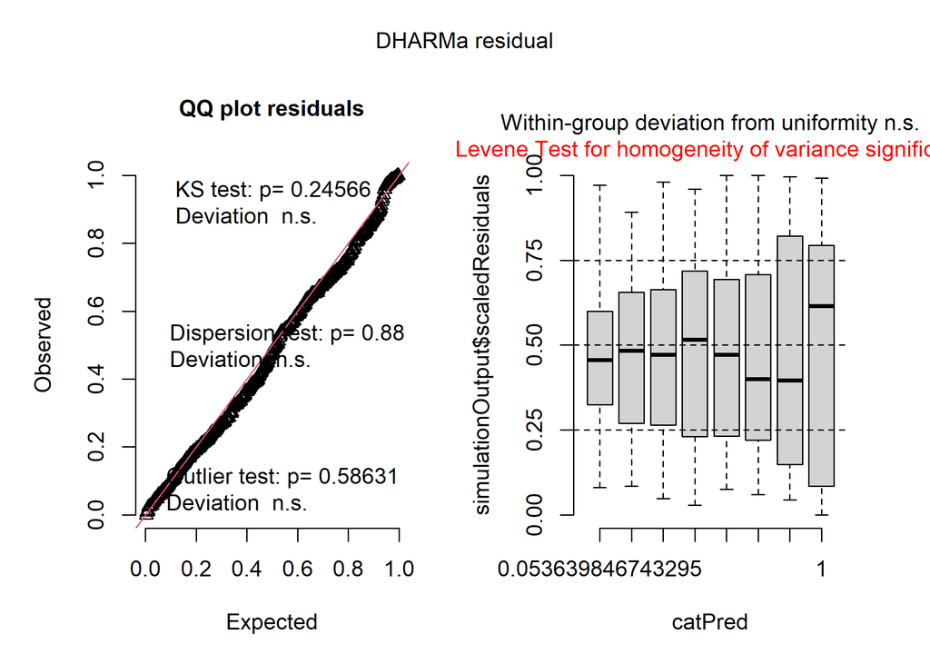

```r
plot(simulateResiduals(modD))
```

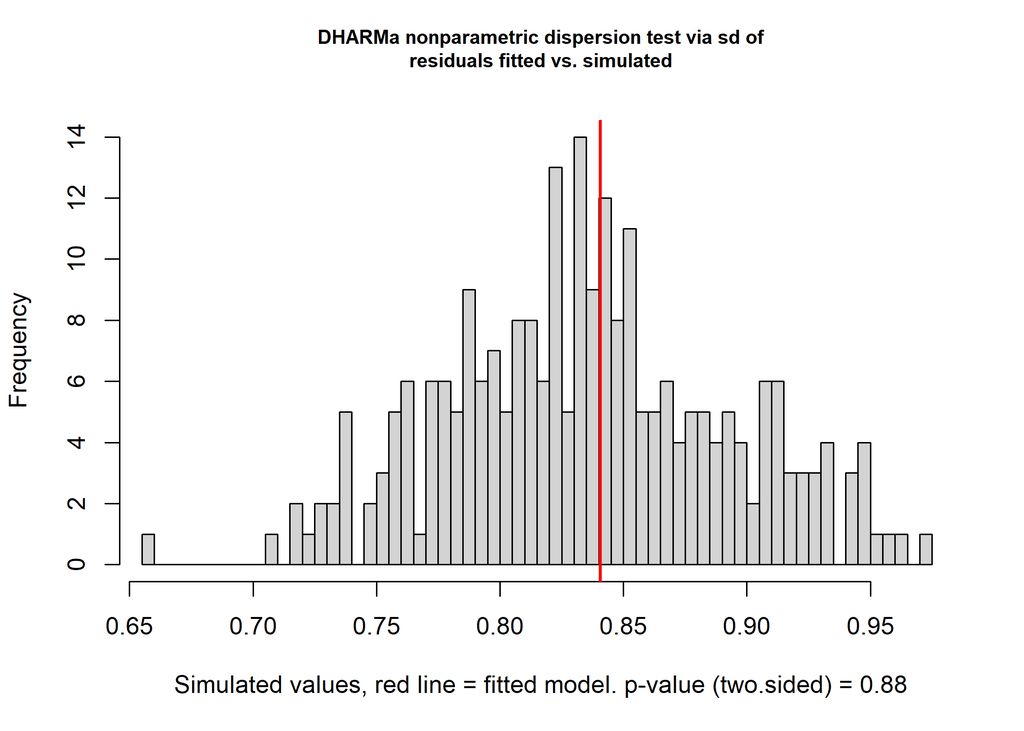

```
##
##  DHARMa nonparametric dispersion test via sd of residuals fitted vs.
##  simulated
##
## data:  simulationOutput
## dispersion = 1.0067, p-value = 0.88
## alternative hypothesis: two.sided
```

```r
testDispersion(simulateResiduals(modD))
```

```r
testZeroInflation(simulateResiduals(modD))
```

```
##
##  DHARMa zero-inflation test via comparison to expected zeros with
##  simulation under H0 = fitted model
##
## data:  simulationOutput
## ratioObsSim = NaN, p-value = 1
## alternative hypothesis: two.sided
```

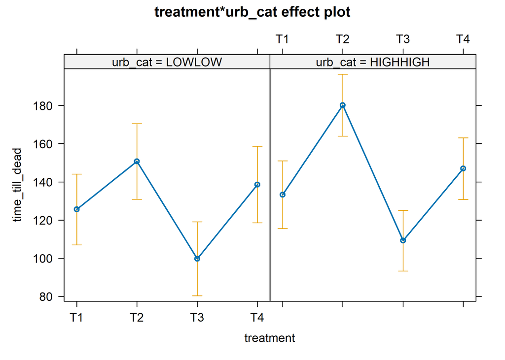

```r
plot(allEffects(modD))
```

```r
contrast(emmeans(modD, specs=~treatment*urb_cat), method="pairwise")
```

```
##  contrast                  estimate    SE  df t.ratio p.value
##  T1 LOWLOW - T2 LOWLOW       -25.15 12.04 415  -2.089  0.4236
##  T1 LOWLOW - T3 LOWLOW        25.78 11.87 415   2.173  0.3704
##  T1 LOWLOW - T4 LOWLOW       -13.04 12.04 415  -1.083  0.9602
##  T1 LOWLOW - T1 HIGHHIGH      -7.72 13.03 415  -0.593  0.9990
##  T1 LOWLOW - T2 HIGHHIGH     -54.60 12.51 415  -4.363  0.0004
##  T1 LOWLOW - T3 HIGHHIGH      16.34 12.43 415   1.315  0.8931
##  T1 LOWLOW - T4 HIGHHIGH     -21.39 12.49 415  -1.712  0.6792
##  T2 LOWLOW - T3 LOWLOW        50.93 12.18 415   4.183  0.0009
##  T2 LOWLOW - T4 LOWLOW        12.10 12.40 415   0.976  0.9776
##  T2 LOWLOW - T1 HIGHHIGH      17.42 13.50 415   1.291  0.9021
##  T2 LOWLOW - T2 HIGHHIGH     -29.46 13.00 415  -2.266  0.3149
##  T2 LOWLOW - T3 HIGHHIGH      41.48 12.92 415   3.212  0.0305
##  T2 LOWLOW - T4 HIGHHIGH       3.76 12.98 415   0.289  1.0000
##  T3 LOWLOW - T4 LOWLOW       -38.83 12.14 415  -3.198  0.0319
##  T3 LOWLOW - T1 HIGHHIGH     -33.51 13.33 415  -2.514  0.1924
##  T3 LOWLOW - T2 HIGHHIGH     -80.38 12.82 415  -6.269  <.0001
##  T3 LOWLOW - T3 HIGHHIGH      -9.44 12.74 415  -0.741  0.9957
##  T3 LOWLOW - T4 HIGHHIGH     -47.17 12.80 415  -3.685  0.0063
##  T4 LOWLOW - T1 HIGHHIGH       5.32 13.57 415   0.392  0.9999
##  T4 LOWLOW - T2 HIGHHIGH     -41.56 13.08 415  -3.178  0.0339
##  T4 LOWLOW - T3 HIGHHIGH      29.38 12.99 415   2.261  0.3180
##  T4 LOWLOW - T4 HIGHHIGH      -8.35 13.06 415  -0.639  0.9983
##  T1 HIGHHIGH - T2 HIGHHIGH   -46.88 10.04 415  -4.670  0.0001
##  T1 HIGHHIGH - T3 HIGHHIGH    24.06  9.90 415   2.431  0.2293
##  T1 HIGHHIGH - T4 HIGHHIGH   -13.67 10.03 415  -1.362  0.8737
##  T2 HIGHHIGH - T3 HIGHHIGH    70.94  9.17 415   7.733  <.0001
##  T2 HIGHHIGH - T4 HIGHHIGH    33.21  9.26 415   3.585  0.0089
##  T3 HIGHHIGH - T4 HIGHHIGH   -37.73  9.16 415  -4.121  0.0012
##
## P value adjustment: tukey method for comparing a family of 8 estimates
```

```r
modD_comp <- contrast(emmeans(modD, specs=~treatment*urb_cat), method="pairwise") |> as_tibble()
modD_comp %>% filter(p.value < 0.099) |> knitr::kable()
```

| contrast | estimate | SE | df | t.ratio | p.value |
| --- | --- | --- | --- | --- | --- |
| T1 LOWLOW - T2 HIGHHIGH | -54.60163 | 12.513331 | 415 | -4.363477 | 0.0004273 |
| T2 LOWLOW - T3 LOWLOW | 50.92922 | 12.175978 | 415 | 4.182762 | 0.0009133 |
| T2 LOWLOW - T3 HIGHHIGH | 41.48456 | 12.915589 | 415 | 3.211976 | 0.0305424 |
| T3 LOWLOW - T4 LOWLOW | -38.82501 | 12.140436 | 415 | -3.197991 | 0.0318821 |
| T3 LOWLOW - T2 HIGHHIGH | -80.38497 | 12.821767 | 415 | -6.269414 | 0.0000000 |
| T3 LOWLOW - T4 HIGHHIGH | -47.17307 | 12.799765 | 415 | -3.685464 | 0.0062525 |
| T4 LOWLOW - T2 HIGHHIGH | -41.55996 | 13.077988 | 415 | -3.177856 | 0.0339010 |
| T1 HIGHHIGH - T2 HIGHHIGH | -46.87742 | 10.037947 | 415 | -4.670021 | 0.0001099 |
| T2 HIGHHIGH - T3 HIGHHIGH | 70.94031 | 9.173553 | 415 | 7.733134 | 0.0000000 |
| T2 HIGHHIGH - T4 HIGHHIGH | 33.21189 | 9.264988 | 415 | 3.584667 | 0.0089494 |
| T3 HIGHHIGH - T4 HIGHHIGH | -37.72842 | 9.155880 | 415 | -4.120676 | 0.0011770 |

## survival analysis

test survival analysis log-rank test comparing survival curves time_till_dead (in days)

```r
library(survival)
library(survminer)
survdiff(Surv(time_till_dead)~treatment+urb_cat, data=df_dead)
```

```
## Call:
## survdiff(formula = Surv(time_till_dead) ~ treatment + urb_cat,
##     data = df_dead)
##
##                                 N Observed Expected (O-E)^2/E (O-E)^2/V
## treatment=T1, urb_cat=LOWLOW   45       45     35.7     2.434     2.804
## treatment=T1, urb_cat=HIGHHIGH 52       52     47.4     0.448     0.532
## treatment=T2, urb_cat=LOWLOW   39       39     47.6     1.559     1.874
## treatment=T2, urb_cat=HIGHHIGH 68       68    121.4    23.463    39.988
## treatment=T3, urb_cat=LOWLOW   41       41     19.3    24.389    27.152
## treatment=T3, urb_cat=HIGHHIGH 72       72     39.7    26.371    31.604
## treatment=T4, urb_cat=LOWLOW   39       39     36.3     0.198     0.233
## treatment=T4, urb_cat=HIGHHIGH 69       69     77.7     0.967     1.287
##
##  Chisq= 97.3  on 7 degrees of freedom, p= <2e-16
```

```r
t<-pairwise_survdiff(Surv(time_till_dead)~treatment+urb_cat, data=df_dead)
t$p.value |> knitr::kable()
```

|  | treatment=T1, urb_cat=LOWLOW | treatment=T1, urb_cat=HIGHHIGH | treatment=T2, urb_cat=LOWLOW | treatment=T2, urb_cat=HIGHHIGH | treatment=T3, urb_cat=LOWLOW | treatment=T3, urb_cat=HIGHHIGH | treatment=T4, urb_cat=LOWLOW |
| --- | --- | --- | --- | --- | --- | --- | --- |
| treatment=T1, urb_cat=HIGHHIGH | 0.4401805 | NA | NA | NA | NA | NA | NA |
| treatment=T2, urb_cat=LOWLOW | 0.0170353 | 0.0562720 | NA | NA | NA | NA | NA |
| treatment=T2, urb_cat=HIGHHIGH | 0.0000067 | 0.0000156 | 0.0254884 | NA | NA | NA | NA |
| treatment=T3, urb_cat=LOWLOW | 0.0094887 | 0.0005651 | 0.0001250 | 0.0000000 | NA | NA | NA |
| treatment=T3, urb_cat=HIGHHIGH | 0.0170353 | 0.0003399 | 0.0000386 | 0.0000000 | 0.3335934 | NA | NA |
| treatment=T4, urb_cat=LOWLOW | 0.4920551 | 0.8930651 | 0.1537476 | 0.0001454 | 0.0013984 | 0.0014515 | NA |
| treatment=T4, urb_cat=HIGHHIGH | 0.0656060 | 0.2696384 | 0.5847701 | 0.0018328 | 0.0000093 | 0.0000056 | 0.3153345 |

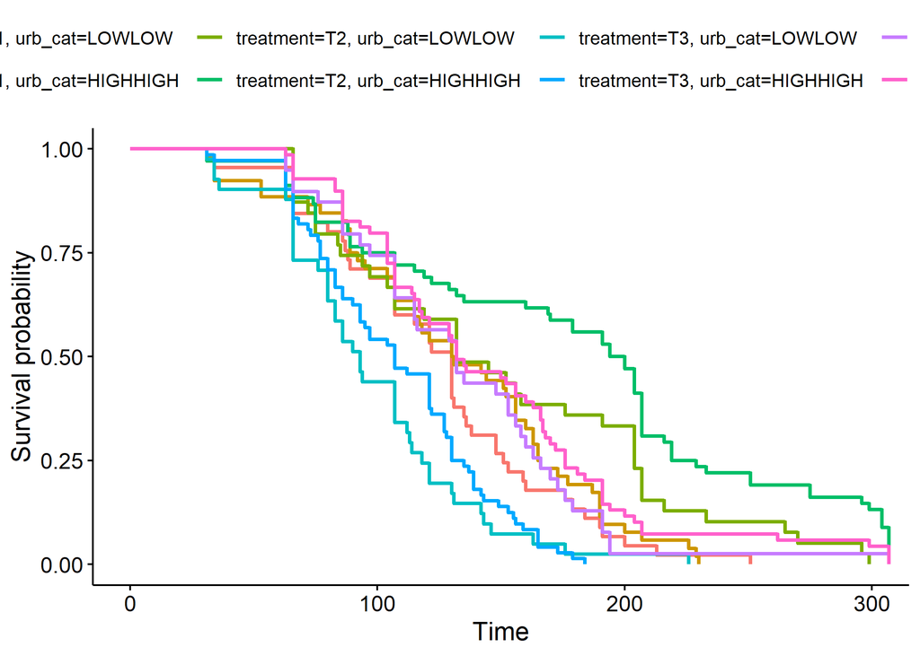

```r
ggsurvplot(survfit(Surv(time_till_dead)~treatment+urb_cat, data=df_dead), data=df_dead, conf.int=F)
```

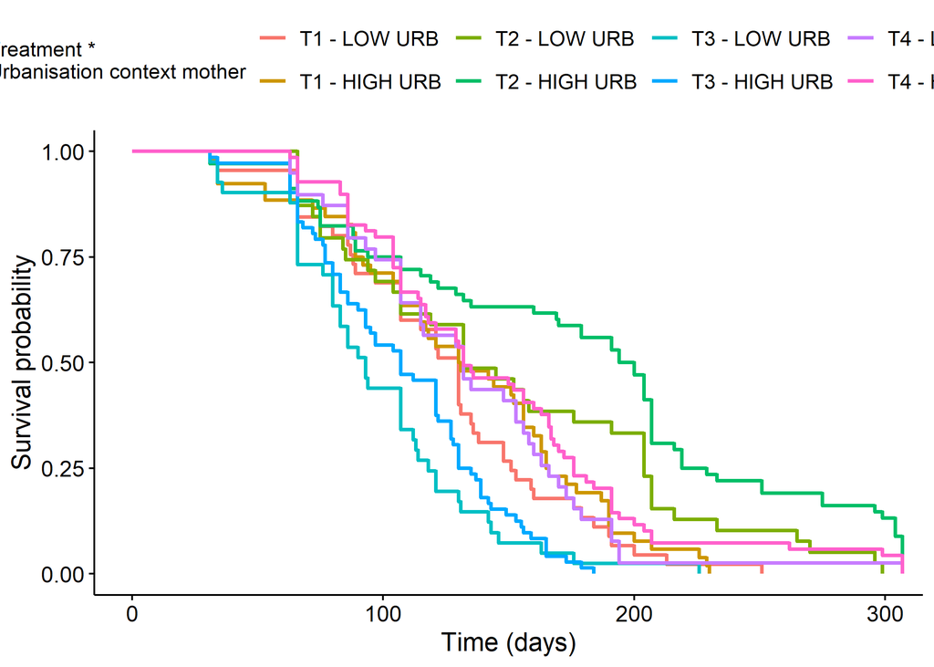

```r
ggsurvplot(survfit(Surv(time_till_dead)~treatment+urb_cat, data=df_dead), data=df_dead, conf.int=F,
           legend.labs=c("T1 - LOW URB", "T1 - HIGH URB", "T2 - LOW URB", "T2 - HIGH URB", "T3 - LOW URB",
                         "T3 - HIGH URB", "T4 - LOW URB", "T4 - HIGH URB"), size=1, risk.table.col="black", font.legend=11, xlab="Time (days)", legend.title="Treatment * \nUrbanisation context mother")
```

```r
survdiff(Surv(time_till_dead)~treatment, data=df_dead) #check for significant differences in survival between treatments
```

```
## Call:
## survdiff(formula = Surv(time_till_dead) ~ treatment, data = df_dead)
##
##                N Observed Expected (O-E)^2/E (O-E)^2/V
## treatment=T1  97       97     83.1     2.335     3.109
## treatment=T2 107      107    169.0    22.732    45.959
## treatment=T3 113      113     59.0    49.524    64.144
## treatment=T4 108      108    114.0     0.315     0.468
##
##  Chisq= 90  on 3 degrees of freedom, p= <2e-16
```

```r
pairwise_survdiff(Surv(time_till_dead)~treatment, data=df_dead)
```

```
##
##  Pairwise comparisons using Log-Rank test
##
## data:  df_dead and treatment
##
##    T1      T2      T3
## T2 1.4e-07 -       -
## T3 8.1e-06 4.0e-15 -
## T4 0.10905 0.00037 4.4e-09
##
## P value adjustment method: BH
```

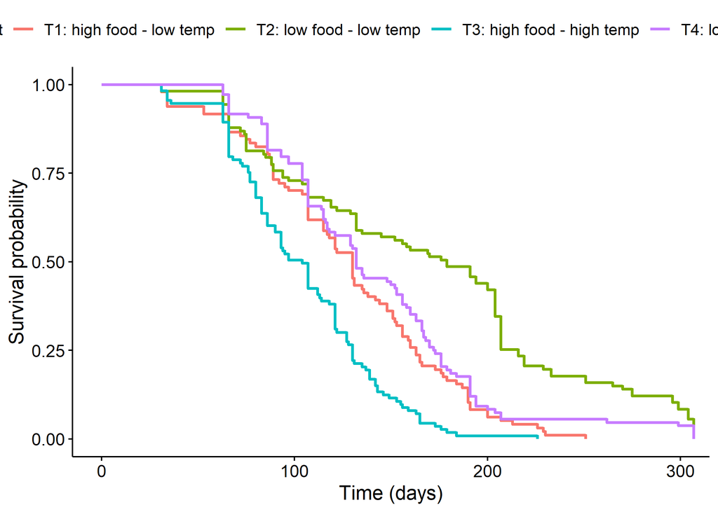

```r
ggsurvplot(survfit(Surv(time_till_dead)~treatment, data=df_dead), data=df_dead, conf.int=F,
           legend.labs=c("T1: high food - low temp", "T2: low food - low temp", "T3: high food - high temp", "T4: low food - high temp"), size=1, risk.table.col="black", font.legend=11, xlab="Time (days)", legend.title="Treatment")
```

```r
survdiff(Surv(time_till_dead)~urb_cat, data=df_dead) # check for significant differences in survival between urb_cat
```

```
## Call:
## survdiff(formula = Surv(time_till_dead) ~ urb_cat, data = df_dead)
##
##                    N Observed Expected (O-E)^2/E (O-E)^2/V
## urb_cat=LOWLOW   164      164      139      4.53      7.25
## urb_cat=HIGHHIGH 261      261      286      2.20      7.25
##
##  Chisq= 7.2  on 1 degrees of freedom, p= 0.007
```

```r
pairwise_survdiff(Surv(time_till_dead)~urb_cat, data=df_dead)
```

```
##
##  Pairwise comparisons using Log-Rank test
##
## data:  df_dead and urb_cat
##
##          LOWLOW
## HIGHHIGH 0.0071
##
## P value adjustment method: BH
```

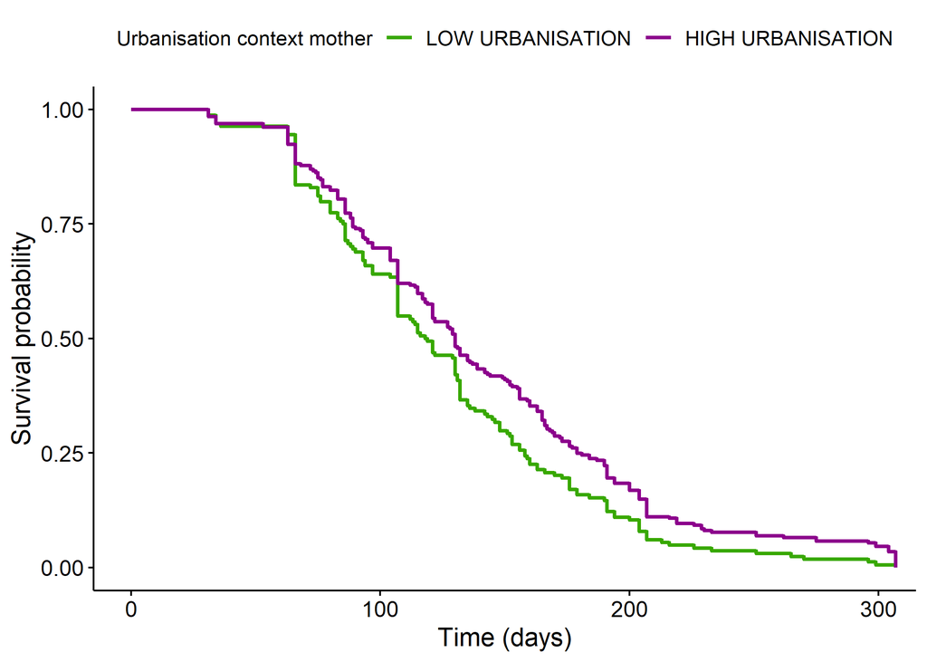

```r
ggsurvplot(survfit(Surv(time_till_dead)~urb_cat, data=df_dead), data=df_dead, conf.int=F,
           legend.labs=c("LOW URBANISATION", "HIGH URBANISATION"), size=1, risk.table.col="black",
           palette=urb.col2, font.legend=11, xlab="Time (days)", legend.title="Urbanisation context mother")
```

```r
survdiff(Surv(time_till_dead)~motherID, data=df_dead) ## should be added as random factor
```

```
## Call:
## survdiff(formula = Surv(time_till_dead) ~ motherID, data = df_dead)
##
##                        N Observed Expected (O-E)^2/E (O-E)^2/V
## motherID=SC22COUP02    6        6    9.799  1.47e+00  1.77e+00
## motherID=SC22COUP07   29       29   38.801  2.48e+00  2.89e+00
## motherID=SC22P02SRE07 15       15   11.051  1.41e+00  1.52e+00
## motherID=SC22P03SRE01 33       33   48.154  4.77e+00  6.19e+00
## motherID=SC22P07SG03  14       14   16.614  4.11e-01  4.51e-01
## motherID=SC22P08SGE03  1        1    0.996  1.48e-05  1.54e-05
## motherID=SC22P09SGE04 11       11    6.714  2.74e+00  2.90e+00
## motherID=SC22P10SR09  34       34   46.586  3.40e+00  4.25e+00
## motherID=SC22P11SRE02 47       47   36.502  3.02e+00  3.47e+00
## motherID=SC22P11SRE13 22       22   20.587  9.70e-02  1.12e-01
## motherID=SC22P12SRE01 14       14   16.423  3.58e-01  3.93e-01
## motherID=SC22P12SRE03 21       21   19.573  1.04e-01  1.15e-01
## motherID=SC22P12SRE05  5        5    8.810  1.65e+00  2.02e+00
## motherID=SC22P16SG04   3        3    1.556  1.34e+00  1.40e+00
## motherID=SC22P17SG09  19       19   13.054  2.71e+00  2.94e+00
## motherID=SC22P17SGE07  2        2    0.207  1.55e+01  1.61e+01
## motherID=SC22P18SGE03 17       17   14.808  3.25e-01  3.52e-01
## motherID=SC22P19SRE09  6        6    6.098  1.57e-03  1.67e-03
## motherID=SC22P20SR13  18       18   10.135  6.10e+00  6.53e+00
## motherID=SC22P21SRE02 11       11   13.562  4.84e-01  5.30e-01
## motherID=SC22P25SGE02  6        6   10.995  2.27e+00  2.49e+00
## motherID=SC22P25SGE07  8        8    6.417  3.90e-01  4.15e-01
## motherID=SC22P25SGE08 17       17   22.572  1.38e+00  1.53e+00
## motherID=SC22P26SG01  22       22   16.937  1.51e+00  1.65e+00
## motherID=SC22P26SGE01  7        7    5.419  4.61e-01  4.86e-01
## motherID=SC22P27SGE11 11       11   11.686  4.03e-02  4.77e-02
## motherID=SC22P27SGE14 26       26   10.945  2.07e+01  2.25e+01
##
##  Chisq= 84.5  on 26 degrees of freedom, p= 4e-08
```

```r
pairwise_survdiff(Surv(time_till_dead)~motherID, data=df_dead)
```

```
##
##  Pairwise comparisons using Log-Rank test
##
## data:  df_dead and motherID
##
##              SC22COUP02 SC22COUP07 SC22P02SRE07 SC22P03SRE01 SC22P07SG03
## SC22COUP07   0.74888    -          -            -            -
## SC22P02SRE07 0.36840    0.13989    -            -            -
## SC22P03SRE01 0.93554    0.79957    0.14544      -            -
## SC22P07SG03  0.67112    0.77219    0.30333      0.72171      -
## SC22P08SGE03 0.91108    0.79957    0.82102      0.92504      0.96314
## SC22P09SGE04 0.28278    0.08536    0.72171      0.07673      0.24129
## SC22P10SR09  0.81845    0.96610    0.16895      0.91344      0.77219
## SC22P11SRE02 0.39429    0.08536    0.92698      0.07897      0.37255
## SC22P11SRE13 0.46680    0.46624    0.80730      0.30082      0.70573
## SC22P12SRE01 0.72171    0.85039    0.44659      0.70494      0.97725
## SC22P12SRE03 0.53786    0.27107    0.66022      0.34616      0.65547
## SC22P12SRE05 0.99384    0.67831    0.37255      0.87182      0.67112
## SC22P16SG04  0.29981    0.21461    0.81677      0.24424      0.22070
## SC22P17SG09  0.30333    0.10173    0.97725      0.08536      0.35144
## SC22P17SGE07 0.04407    0.00251    0.10808      0.00077      0.01079
## SC22P18SGE03 0.46680    0.26908    0.77219      0.28278      0.63568
## SC22P19SRE09 0.65693    0.63568    0.68589      0.67046      0.81677
## SC22P20SR13  0.22726    0.02730    0.56651      0.02568      0.16328
## SC22P21SRE02 0.66022    0.85436    0.35196      0.77219      0.99470
## SC22P25SGE02 0.96314    0.81677    0.12702      0.77219      0.66022
## SC22P25SGE07 0.54243    0.34987    0.78957      0.37255      0.67831
## SC22P25SGE08 0.99384    0.91223    0.16739      0.95587      0.97725
## SC22P26SG01  0.30333    0.16004    0.96219      0.11292      0.43766
## SC22P26SGE01 0.47141    0.30333    0.96883      0.34987      0.55586
## SC22P27SGE11 0.57178    0.70494    0.70081      0.54423      0.92504
## SC22P27SGE14 0.03013    0.00110    0.22854      0.00063      0.01079
##              SC22P08SGE03 SC22P09SGE04 SC22P10SR09 SC22P11SRE02 SC22P11SRE13
## SC22COUP07   -            -            -           -            -
## SC22P02SRE07 -            -            -           -            -
## SC22P03SRE01 -            -            -           -            -
## SC22P07SG03  -            -            -           -            -
## SC22P08SGE03 -            -            -           -            -
## SC22P09SGE04 0.79957      -            -           -            -
## SC22P10SR09  0.82695      0.11778      -           -            -
```

[output cut: 114 more lines]

```
## SC22P17SG09  -
## SC22P17SGE07 -
## SC22P18SGE03 -
## SC22P19SRE09 -
## SC22P20SR13  -
## SC22P21SRE02 -
## SC22P25SGE02 -
## SC22P25SGE07 -
## SC22P25SGE08 -
## SC22P26SG01  -
## SC22P26SGE01 -
## SC22P27SGE11 -
## SC22P27SGE14 0.07673
##
## P value adjustment method: BH
```

```r
survdiff(Surv(time_till_dead)~treatment, data=subset(df_dead, urb_cat=="HIGHHIGH"))
```

```
## Call:
## survdiff(formula = Surv(time_till_dead) ~ treatment, data = subset(df_dead,
##     urb_cat == "HIGHHIGH"))
##
##               N Observed Expected (O-E)^2/E (O-E)^2/V
## treatment=T1 52       52     43.2    1.8125    2.3096
## treatment=T2 68       68    110.8   16.5608   35.5930
## treatment=T3 72       72     36.2   35.3750   46.3947
## treatment=T4 69       69     70.8    0.0452    0.0676
##
##  Chisq= 66.2  on 3 degrees of freedom, p= 3e-14
```

```r
pairwise_survdiff(Surv(time_till_dead)~treatment, data=subset(df_dead, urb_cat=="HIGHHIGH"))
```

```
##
##  Pairwise comparisons using Log-Rank test
##
## data:  subset(df_dead, urb_cat == "HIGHHIGH") and treatment
##
##    T1      T2      T3
## T2 6.7e-06 -       -
## T3 0.00018 8.3e-12 -
## T4 0.21186 0.00110 1.8e-06
##
## P value adjustment method: BH
```

```r
survdiff(Surv(time_till_dead)~treatment, data=subset(df_dead, urb_cat=="LOWLOW"))
```

```
## Call:
## survdiff(formula = Surv(time_till_dead) ~ treatment, data = subset(df_dead,
##     urb_cat == "LOWLOW"))
##
##               N Observed Expected (O-E)^2/E (O-E)^2/V
## treatment=T1 45       45     41.6     0.286     0.413
## treatment=T2 39       39     57.3     5.837    10.510
## treatment=T3 41       41     22.3    15.689    20.066
## treatment=T4 39       39     42.9     0.348     0.515
##
##  Chisq= 25.5  on 3 degrees of freedom, p= 1e-05
```

```r
pairwise_survdiff(Surv(time_till_dead)~treatment, data=subset(df_dead, urb_cat=="LOWLOW"))
```

```
##
##  Pairwise comparisons using Log-Rank test
##
## data:  subset(df_dead, urb_cat == "LOWLOW") and treatment
##
##    T1      T2      T3
## T2 0.01536 -       -
## T3 0.01017 0.00021 -
## T4 0.45691 0.13837 0.00180
##
## P value adjustment method: BH
```

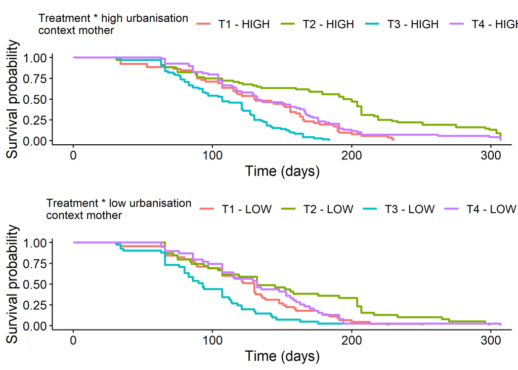

```r
f1<-ggsurvplot(survfit(Surv(time_till_dead)~treatment+urb_cat, data=subset(df_dead, urb_cat=="HIGHHIGH")), data=subset(df_dead, urb_cat=="HIGHHIGH"), conf.int=F, legend.labs=c("T1 - HIGH", "T2 - HIGH", "T3 - HIGH", "T4 - HIGH"),
           size=1, risk.table.col="black", font.legend=11, xlab="Time (days)", legend.title="Treatment * high urbanisation \ncontext mother")
f2<-ggsurvplot(survfit(Surv(time_till_dead)~treatment+urb_cat, data=subset(df_dead, urb_cat=="LOWLOW")), data=subset(df_dead, urb_cat=="LOWLOW"), conf.int=F, legend.labs=c("T1 - LOW", "T2 - LOW", "T3 - LOW", "T4 - LOW"),
           size=1, risk.table.col="black", font.legend=11, xlab="Time (days)", legend.title="Treatment * low urbanisation \ncontext mother")
fig1 <- f1$plot
fig2 <- f2$plot
ggarrange(fig1, fig2, nrow=2, heights=c(2,2))
```

```r
##ggsurvplot(survfit(Surv(time_till_dead)~motherID, data=df_dead), data=df_dead, conf.int=T)
##survdiff(Surv(time_till_dead)~treatment+urb_cat+strata(motherID), data=df_dead) ## wrong?
```